# Paluu tulevaisuuteen

### 3.1.3 Poolaus

Kootaan reitit 50 km x 50 km (tai 100x100 km) ruutuihin, eli lasketaan todelliset ja ennustetut esiintymistodennäköisyydet kaikkien yhteen ruutuun sijoittuvien reittien periodien keskiarvojen keskiarvoina.

Luetaan ensin kaikki aineisto koordinaatteineen sisälle.  
Ay1 ja 2 ovat todellisia havaintoja, periodeittain. Ap1 ja 2 ovat ennusteita.

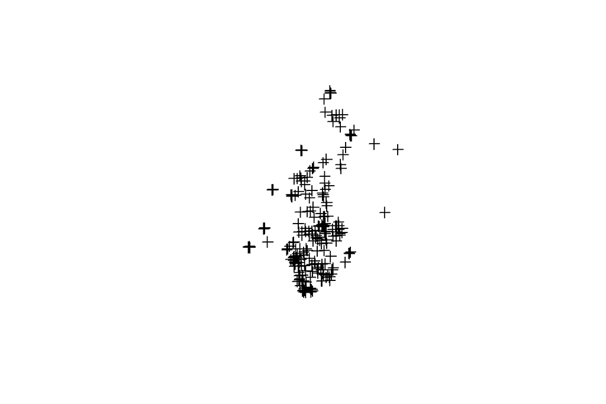

```r
#luetaan sisään reitit, havainnot ja ennusteet
coordinates(Ay1)<-c("x","y")
plot(Ay1)
```

```r
proj4string(Ay1) <-CRS("+init=EPSG:3035")

coordinates(Ay2)<-c("x","y")
proj4string(Ay2) <-CRS("+init=EPSG:3035")

coordinates(Ap1)<-c("x","y")
proj4string(Ap1) <-CRS("+init=EPSG:3035")

coordinates(Ap2)<-c("x","y")
proj4string(Ap2) <-CRS("+init=EPSG:3035")
```

Gridit olen tehnyt jo aiemmin QGis:llä.

```r
gridi<- readOGR(dsn="./gridit", layer="grid50km")
#gridi<- readOGR(dsn="./gridit", layer="grid100km")
proj4string(gridi)
```

```
## [1] "+proj=laea +lat_0=52 +lon_0=10 +x_0=4321000 +y_0=3210000 +ellps=GRS80 +units=m +no_defs"
```

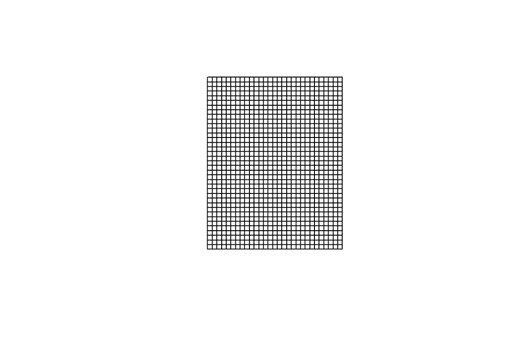

```r
plot(gridi)
```

Itse poolaus tapahtuu niin, että liitetään kuhunkin reittiin tieto, millä gridin ruudulla (id-numero) se on, jonka jälkeen ryhmitellään kaikki reitit gridiruuduittain ja lasketaan niille keskiarvot. Tallennan taas kaikki tiedot niin, että ne on helppo lukea ja tarkistaa GIS:llä.

```r
#liitetään kuhunkin reittiin tieto, millä gridin ruudulla se on
pts.poly <- point.in.poly(Ay1, gridi)
data<-as.data.frame(pts.poly)

#ryhmitelään linjat gridiruuduittain ja lasketaan keskiarvot kullekin sarakkeelle, eli lajeittain.
data%>%
  group_by(grid_id) %>%
  summarise_at(vars(-Route), list(~mean(., na.rm=T))) %>% #jos jollain lajilla on yhdellä linjalla NA:ta se ei vaikuta keskiarvon laskemiseen.
  write.csv(.,file = "pool_pa_obs_per1.csv",row.names=F)

#ja sama muille aineistoille
pts.poly <- point.in.poly(Ay2, gridi)
data<-as.data.frame(pts.poly)
data%>%
  group_by(grid_id) %>%
  summarise_at(vars(-Route), list(~mean(., na.rm=T))) %>%
  write.csv(.,file = "pool_pa_obs_per2.csv",row.names=F)

pts.poly <- point.in.poly(Ap1, gridi)
data<-as.data.frame(pts.poly)
data%>%
  group_by(grid_id) %>%
  summarise_at(vars(-Route), list(~mean(., na.rm=T))) %>%
  write.csv(.,file = "pool_pa_pred_per1.csv",row.names=F)

pts.poly <- point.in.poly(Ap2, gridi)
data<-as.data.frame(pts.poly)
data%>%
  group_by(grid_id) %>%
  summarise_at(vars(-Route), list(~mean(., na.rm=T))) %>%
  write.csv(.,file = "pool_pa_pred_per2.csv",row.names=F)
```

### 3.1.4 Poolatut ennustustarkkuudet

Lopulta lasketaan uudestaan ennustustarkkuudet poolatuilla arvoilla. Toistaiseksi vain metodilla D.

Luetaan aineisto takaisin sisään ja siivotaan sitä hieman:

```r
#luetaan aineisto takaisin sisään
paY1<-read.csv("pool_pa_obs_per1.csv",header=T,sep=",")
paY2<-read.csv("pool_pa_obs_per2.csv",header=T,sep=",")
papred1<-read.csv("pool_pa_pred_per1.csv",header=T,sep=",")
papred2<-read.csv("pool_pa_pred_per2.csv",header=T,sep=",")

#heivataan turhat sarakkeet
names(paY1)
```

```
##   [1] "grid_id"   "V1"        "V2"        "V3"        "V4"
##   [6] "V5"        "V6"        "V7"        "V8"        "V9"
##  [11] "V10"       "V11"       "V12"       "V13"       "V14"
##  [16] "V15"       "V16"       "V17"       "V18"       "V19"
##  [21] "V20"       "V21"       "V22"       "V23"       "V24"
##  [26] "V25"       "V26"       "V27"       "V28"       "V29"
##  [31] "V30"       "V31"       "V32"       "V33"       "V34"
##  [36] "V35"       "V36"       "V37"       "V38"       "V39"
##  [41] "V40"       "V41"       "V42"       "V43"       "V44"
##  [46] "V45"       "V46"       "V47"       "V48"       "V49"
##  [51] "V50"       "V51"       "V52"       "V53"       "V54"
##  [56] "V55"       "V56"       "V57"       "V58"       "V59"
##  [61] "V60"       "V61"       "V62"       "V63"       "V64"
##  [66] "V65"       "V66"       "V67"       "V68"       "V69"
##  [71] "V70"       "V71"       "V72"       "V73"       "V74"
##  [76] "V75"       "V76"       "V77"       "V78"       "V79"
##  [81] "V80"       "V81"       "V82"       "V83"       "V84"
##  [86] "V85"       "V86"       "V87"       "V88"       "V89"
##  [91] "V90"       "V91"       "V92"       "V93"       "V94"
##  [96] "V95"       "V96"       "V97"       "V98"       "V99"
## [101] "V100"      "V101"      "V102"      "V103"      "V104"
## [106] "V105"      "V106"      "V107"      "V108"      "V109"
## [111] "V110"      "V111"      "V112"      "V113"      "V114"
## [116] "V115"      "V116"      "V117"      "V118"      "V119"
## [121] "V120"      "routeid"   "left"      "top"       "right"
## [126] "bottom"    "coords.x1" "coords.x2"
```

```r
drops <- c("routeid","left","top","right","bottom","coords.x1","coords.x2")
paY1<-paY1[ , !(names(paY1) %in% drops)]
paY2<-paY2[ , !(names(paY2) %in% drops)]
papred1<-papred1[ , !(names(papred1) %in% drops)]
papred2<-papred2[ , !(names(papred2) %in% drops)]

#korjataan sarakkeiden lajinimet kunnollisiksi
a<-colnames(Y)
b<-"grid_id"
a<-c(b,a)

names(paY1)<-a
names(paY2)<-a
names(papred1)<-a
names(papred2)<-a
```

Lasketaan periodien välinen muutos havainnoille ja ennusteille ja näiden korrelaatiot. (primitiivinen koodaus, voi parannella myöhemmin..)

```r
#lasketaan erotukset periodin 1 ja 2 välilä
#pa
#obs
pacounts_gather<-gather(paY1,key="Yspecies",value="Yper1",Acrocephalus_palustris:Vanellus_vanellus)
pacounts_gather2<-gather(paY2,key="Yspecies",value="Yper2",Acrocephalus_palustris:Vanellus_vanellus)
payhd<-left_join(pacounts_gather,pacounts_gather2,by=c("grid_id"="grid_id","Yspecies"="Yspecies"))
payhd$difY<-payhd$Yper2-payhd$Yper1

#pred
papred_gather<-gather(papred1,key="Pspecies",value="Pper1",Acrocephalus_palustris:Vanellus_vanellus)
papred_gather2<-gather(papred2,key="Pspecies",value="Pper2",Acrocephalus_palustris:Vanellus_vanellus)
payhdPred<-left_join(papred_gather,papred_gather2,by=c("grid_id"="grid_id","Pspecies"="Pspecies"))
payhdPred$difPred<-payhdPred$Pper2-payhdPred$Pper1

#yhdistetään tulokset, havainnot ja ennusteet samaan dataframeen
paKor<-left_join(payhd,payhdPred,by=c("grid_id"="grid_id","Yspecies"="Pspecies"))
keep<-c("Yspecies","difPred","difY")
paKor<-paKor[,keep,drop=F]

#lasketaan korrelaatiot
paKor %>%
  group_by(Yspecies) %>%
  dplyr::summarise(pool_pa_change= cor(difPred, difY, use= "na.or.complete"))%T>%
  write.csv('pa_pool50_results.csv',row.names=F)
```

```
## # A tibble: 120 x 2
##    Yspecies                   pool_pa_change
##    <chr>                               <dbl>
##  1 Acrocephalus_palustris            0.351
##  2 Acrocephalus_schoenobaenus        0.264
##  3 Acrocephalus_scirpaceus          -0.252
##  4 Actitis_hypoleucos               -0.181
##  5 Aegithalos_caudatus              -0.0471
##  6 Alauda_arvensis                  -0.273
##  7 Anas_crecca                      -0.168
##  8 Anas_platyrhynchos               -0.00841
##  9 Anser_anser                       0.429
## 10 Anthus_pratensis                  0.0898
## # ... with 110 more rows
```

### 3.1.5 Metodi B

```r
#yhdistetään tulokset, havainnot ja ennusteet samaan dataframeen
paKor<-left_join(payhd,payhdPred,by=c("grid_id"="grid_id","Yspecies"="Pspecies"))

#lasketaan korrelaatiot
paKor_B=paKor %>%
  group_by(Yspecies) %>%
  dplyr::summarise(pool_pa_change= cor(Pper2, Yper2, use= "na.or.complete"))%T>%
  write.csv('pa_pool50_results_methodB.csv',row.names=F)
```

### 3.1.6 Metodit C ja A

```r
getwd()
```

```
## [1] "C:/Users/Sirke Piirainen/OneDrive - University of Helsinki/github_mallinnus/model_validation"
```

```r
localDir = "."
PredictionDir = file.path(localDir, "data")

samples = 1000
thin = 1000 #muista vaihtaa tämä!!
nChains = 4
modeltype = 1 #1 on pa-aineistolle

#model 1: data until 2006; model 2: full data
#mpred1: posterior mean based on model 1; mpred2: posterior mean based on model 2

filename = file.path(PredictionDir, paste("predictions_",c("pa","abundance")[modeltype],
                                          "_chains_",as.character(nChains),"_thin_", as.character(thin),"_samples_", as.character(samples),
                                          ".Rdata",sep = ""))
load(filename) #mpred1, mpred2, Y, studyDesign
routes=levels(studyDesign$Route)
nr=length(routes)
years=levels(studyDesign$Year)
ns=dim(mpred1)[2]

#määritellään periodit
period1=(studyDesign$Year=="Year_1996" | studyDesign$Year=="Year_1997" | studyDesign$Year=="Year_1998" | studyDesign$Year=="Year_1999")
period2=(studyDesign$Year=="Year_2013" | studyDesign$Year=="Year_2014" | studyDesign$Year=="Year_2015" | studyDesign$Year=="Year_2016")

#valitaan ennusteista ja havainnoista oikeat vuodet
pm2p1=mpred2[period1,]
pm2p2=mpred2[period2,] #tähän vaihdetaan mpred2 ja pm2 eli malli2, jonka sovituksessa käytetty koko aineistoa

y1=Y[period1,]
y2=Y[period2,]

#lasketaan kuinka monta kertaa kullakin linjalla on k?yty
sd1 = studyDesign[period1,]
sd2 = studyDesign[period2,]

visits1 = rep(NA,nr)
visits2 = rep(NA,nr)
for (i in 1:nr){
  visits1[i] = sum(sd1$Route==routes[i])
  visits2[i] = sum(sd2$Route==routes[i])
}

#lasketaan kullekin linjalle (jolla on käyty kahdesti kummankin periodin aikana, yhteensä 592 kpl) keskiarvot periodeittain
#havainnot ja ennusteet erikseen, periodit 1 ja 2 erikseen
selroutes = routes[which(visits1>=2 & visits2>=2)]
nsr = length(selroutes)

Ap1=matrix(NA,nrow = nsr,ncol = ns)
Ap2=matrix(NA,nrow = nsr,ncol = ns)
Ay1=matrix(NA,nrow = nsr,ncol = ns)
Ay2=matrix(NA,nrow = nsr,ncol = ns)

for (i in 1:nsr){
  take1 = which(sd1$Route == selroutes[i] )
  take2 = which(sd2$Route == selroutes[i] )
  Ap1[i,] = colMeans(pm2p1[take1,])
  Ap2[i,] = colMeans(pm2p2[take2,])
  Ay1[i,] = colMeans(y1[take1,]) #Suomen vesilinnut vain NA:ta
  Ay2[i,] = colMeans(y2[take2,])
}
```

```r
#matriisit on muutettava dataframeiksi
Ap1=as.data.frame(Ap1)
Ap1=cbind(selroutes,Ap1)
setnames(Ap1,"selroutes","Route")

Ap2=as.data.frame(Ap2)
Ap2=cbind(selroutes,Ap2)
setnames(Ap2,"selroutes","Route")

Ay1=as.data.frame(Ay1)
Ay1=cbind(selroutes,Ay1)
setnames(Ay1,"selroutes","Route")

Ay2=as.data.frame(Ay2)
Ay2=cbind(selroutes,Ay2)
setnames(Ay2,"selroutes","Route")

#lisätään havaintoihin ja ennusteisiin ensin oikeat reittikoodit (1-2591)
Ap1<-left_join(Ap1,d,by="Route")
Ap2<-left_join(Ap2,d,by="Route")
Ay1<-left_join(Ay1,d,by="Route")
Ay2<-left_join(Ay2,d,by="Route")
```

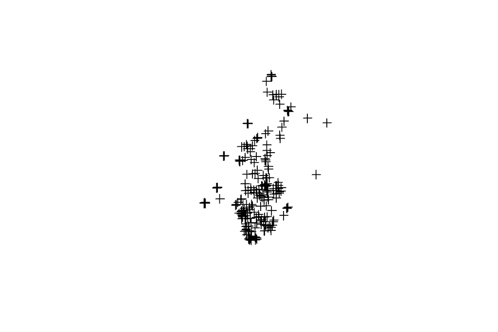

```r
#...ja vihdoin myös koordinaatit
Ap1<-left_join(Ap1,xy,by=c("routeid"="route"))
Ap2<-left_join(Ap2,xy,by=c("routeid"="route"))
Ay1<-left_join(Ay1,xy,by=c("routeid"="route"))
Ay2<-left_join(Ay2,xy,by=c("routeid"="route"))

#tallenna tiedot
write.csv(Ay1,"pa_obs_per1.csv",row.names = F)
write.csv(Ay2,"pa_obs_per2.csv",row.names = F)
write.csv(Ap1,"pa_pred_per1.csv",row.names = F)
write.csv(Ap2,"pa_pred_per2.csv",row.names = F)

#luetaan sisään reitit, havainnot ja ennusteet
coordinates(Ay1)<-c("x","y")
plot(Ay1)
```

```r
proj4string(Ay1) <-CRS("+init=EPSG:3035")

coordinates(Ay2)<-c("x","y")
proj4string(Ay2) <-CRS("+init=EPSG:3035")

coordinates(Ap1)<-c("x","y")
proj4string(Ap1) <-CRS("+init=EPSG:3035")

coordinates(Ap2)<-c("x","y")
proj4string(Ap2) <-CRS("+init=EPSG:3035")

#liitetään kuhunkin reittiin tieto, millä gridin ruudulla se on
pts.poly <- point.in.poly(Ay1, gridi)
data<-as.data.frame(pts.poly)

#ryhmitelään linjat gridiruuduittain ja lasketaan keskiarvot kullekin sarakkeelle, eli lajeittain.
data%>%
  group_by(grid_id) %>%
  summarise_at(vars(-Route), list(~mean(., na.rm=T))) %>% #jos jollain lajilla on yhdellä linjalla NA:ta se ei vaikuta keskiarvon laskemiseen.
  write.csv(.,file = "pool_pa_obs_per1.csv",row.names=F)

#ja sama muille aineistoille
pts.poly <- point.in.poly(Ay2, gridi)
data<-as.data.frame(pts.poly)
data%>%
  group_by(grid_id) %>%
  summarise_at(vars(-Route), list(~mean(., na.rm=T))) %>%
  write.csv(.,file = "pool_pa_obs_per2.csv",row.names=F)

pts.poly <- point.in.poly(Ap1, gridi)
data<-as.data.frame(pts.poly)
data%>%
  group_by(grid_id) %>%
  summarise_at(vars(-Route), list(~mean(., na.rm=T))) %>%
  write.csv(.,file = "pool_pa_pred_per1.csv",row.names=F)

pts.poly <- point.in.poly(Ap2, gridi)
data<-as.data.frame(pts.poly)
data%>%
  group_by(grid_id) %>%
  summarise_at(vars(-Route), list(~mean(., na.rm=T))) %>%
  write.csv(.,file = "pool_pa_pred_per2.csv",row.names=F)

#luetaan aineisto takaisin sisään
paY1<-read.csv("pool_pa_obs_per1.csv",header=T,sep=",")
paY2<-read.csv("pool_pa_obs_per2.csv",header=T,sep=",")
papred1<-read.csv("pool_pa_pred_per1.csv",header=T,sep=",")
papred2<-read.csv("pool_pa_pred_per2.csv",header=T,sep=",")

#heivataan turhat sarakkeet
names(paY1)
```

```
##   [1] "grid_id"   "V1"        "V2"        "V3"        "V4"
##   [6] "V5"        "V6"        "V7"        "V8"        "V9"
##  [11] "V10"       "V11"       "V12"       "V13"       "V14"
##  [16] "V15"       "V16"       "V17"       "V18"       "V19"
##  [21] "V20"       "V21"       "V22"       "V23"       "V24"
##  [26] "V25"       "V26"       "V27"       "V28"       "V29"
##  [31] "V30"       "V31"       "V32"       "V33"       "V34"
##  [36] "V35"       "V36"       "V37"       "V38"       "V39"
##  [41] "V40"       "V41"       "V42"       "V43"       "V44"
##  [46] "V45"       "V46"       "V47"       "V48"       "V49"
##  [51] "V50"       "V51"       "V52"       "V53"       "V54"
##  [56] "V55"       "V56"       "V57"       "V58"       "V59"
##  [61] "V60"       "V61"       "V62"       "V63"       "V64"
##  [66] "V65"       "V66"       "V67"       "V68"       "V69"
##  [71] "V70"       "V71"       "V72"       "V73"       "V74"
##  [76] "V75"       "V76"       "V77"       "V78"       "V79"
##  [81] "V80"       "V81"       "V82"       "V83"       "V84"
##  [86] "V85"       "V86"       "V87"       "V88"       "V89"
##  [91] "V90"       "V91"       "V92"       "V93"       "V94"
##  [96] "V95"       "V96"       "V97"       "V98"       "V99"
## [101] "V100"      "V101"      "V102"      "V103"      "V104"
## [106] "V105"      "V106"      "V107"      "V108"      "V109"
## [111] "V110"      "V111"      "V112"      "V113"      "V114"
## [116] "V115"      "V116"      "V117"      "V118"      "V119"
## [121] "V120"      "routeid"   "left"      "top"       "right"
## [126] "bottom"    "coords.x1" "coords.x2"
```

```r
drops <- c("routeid","left","top","right","bottom","coords.x1","coords.x2")
paY1<-paY1[ , !(names(paY1) %in% drops)]
paY2<-paY2[ , !(names(paY2) %in% drops)]
papred1<-papred1[ , !(names(papred1) %in% drops)]
papred2<-papred2[ , !(names(papred2) %in% drops)]

#korjataan sarakkeiden lajinimet kunnollisiksi
a<-colnames(Y)
b<-"grid_id"
a<-c(b,a)

names(paY1)<-a
names(paY2)<-a
names(papred1)<-a
names(papred2)<-a

#lasketaan erotukset periodin 1 ja 2 välilä
#pa
#obs
pacounts_gather<-gather(paY1,key="Yspecies",value="Yper1",Acrocephalus_palustris:Vanellus_vanellus)
pacounts_gather2<-gather(paY2,key="Yspecies",value="Yper2",Acrocephalus_palustris:Vanellus_vanellus)
payhd<-left_join(pacounts_gather,pacounts_gather2,by=c("grid_id"="grid_id","Yspecies"="Yspecies"))
payhd$difY<-payhd$Yper2-payhd$Yper1

#pred
papred_gather<-gather(papred1,key="Pspecies",value="Pper1",Acrocephalus_palustris:Vanellus_vanellus)
papred_gather2<-gather(papred2,key="Pspecies",value="Pper2",Acrocephalus_palustris:Vanellus_vanellus)
payhdPred<-left_join(papred_gather,papred_gather2,by=c("grid_id"="grid_id","Pspecies"="Pspecies"))
payhdPred$difPred<-payhdPred$Pper2-payhdPred$Pper1

#yhdistetään tulokset, havainnot ja ennusteet samaan dataframeen
paKor<-left_join(payhd,payhdPred,by=c("grid_id"="grid_id","Yspecies"="Pspecies"))
keep<-c("Yspecies","difPred","difY")
paKor<-paKor[,keep,drop=F]

#lasketaan korrelaatiot, metodi C
paKor_C=paKor %>%
  group_by(Yspecies) %>%
  dplyr::summarise(pool_pa_change= cor(difPred, difY, use= "na.or.complete"))%T>%
  write.csv('pa_pool50_results_methodC.csv',row.names=F)

#method A

#yhdistetään tulokset, havainnot ja ennusteet samaan dataframeen
paKor<-left_join(payhd,payhdPred,by=c("grid_id"="grid_id","Yspecies"="Pspecies"))

#lasketaan korrelaatiot
paKor_A=paKor %>%
  group_by(Yspecies) %>%
  dplyr::summarise(pool_pa_change= cor(Pper2, Yper2, use= "na.or.complete"))%T>%
  write.csv('pa_pool50_results_methodA.csv',row.names=F)
```

## 3.2 Abundance -aineisto

Tehdään sama proseduuri myös abu-aineistolle.

### 3.2.1 Aineisto sisälle ja periodien keskiarvojen lasku

```r
modeltype = 2 #2 on abu-aineistolle

#model 1: data until 2006; model 2: full data
#mpred1: posterior mean based on model 1; mpred2: posterior mean based on model 2

filename = file.path(PredictionDir, paste("predictions_",c("pa","abundance")[modeltype],
                                          "_chains_",as.character(nChains),"_thin_", as.character(thin),"_samples_", as.character(samples),
                                          ".Rdata",sep = ""))
load(filename) #mpred1, mpred2, Y, studyDesign
routes=levels(studyDesign$Route)
nr=length(routes)
years=levels(studyDesign$Year)
ns=dim(mpred1)[2]

period1=(studyDesign$Year=="Year_1996" | studyDesign$Year=="Year_1997" | studyDesign$Year=="Year_1998" | studyDesign$Year=="Year_1999")
period2=(studyDesign$Year=="Year_2013" | studyDesign$Year=="Year_2014" | studyDesign$Year=="Year_2015" | studyDesign$Year=="Year_2016")

pm1p1=mpred1[period1,]
pm1p2=mpred1[period2,] #pm1p2 = predictions by model 1 to period 2

y1=Y[period1,]
y2=Y[period2,]

sd1 = studyDesign[period1,]
sd2 = studyDesign[period2,]

visits1 = rep(NA,nr)
visits2 = rep(NA,nr)
for (i in 1:nr){
  visits1[i] = sum(sd1$Route==routes[i])
  visits2[i] = sum(sd2$Route==routes[i])
}

# lasketaan kullekin linjalle (jolla on k?yty kahdesti kummankin periodin aikana) keskiarvot periodeittain
#havainnot ja ennusteet erikseen
selroutes = routes[which(visits1>=2 & visits2>=2)]
nsr = length(selroutes)

Ap1=matrix(NA,nrow = nsr,ncol = ns)
Ap2=matrix(NA,nrow = nsr,ncol = ns)
Ay1=matrix(NA,nrow = nsr,ncol = ns)
Ay2=matrix(NA,nrow = nsr,ncol = ns)

for(j in 1:ns){
  for (i in 1:nsr){
    take1 = which(sd1$Route == selroutes[i] & y1[,j]>-1)
    take2 = which(sd2$Route == selroutes[i] & y2[,j]>-1)
    Ap1[i,j] = mean(pm1p1[take1,j]) #ei laske ennusteille keskiarvoa niiltä linjoilta, jotka ovat havainnoissa NA
    Ap2[i,j] = mean(pm1p2[take2,j])
    Ay1[i,j] = mean(y1[take1,j], na.rm=T) #NA:t jätetään huomiotta keskiarvoa laskettaessa
    Ay2[i,j] = mean(y2[take2,j], na.rm=T)
  }}
```

### 3.2.2 Koordinaattien lisääminen

```r
#matriisit on muutettava dataframeiksi
Ap1=as.data.frame(Ap1)
Ap1=cbind(selroutes,Ap1)
setnames(Ap1,"selroutes","Route")

Ap2=as.data.frame(Ap2)
Ap2=cbind(selroutes,Ap2)
setnames(Ap2,"selroutes","Route")

Ay1=as.data.frame(Ay1)
Ay1=cbind(selroutes,Ay1)
setnames(Ay1,"selroutes","Route")

Ay2=as.data.frame(Ay2)
Ay2=cbind(selroutes,Ay2)
setnames(Ay2,"selroutes","Route")

#lisätään havaintoihin ja ennusteisiin ensin oikeat reittikoodit (1-2591)
Ap1<-left_join(Ap1,d,by="Route")
Ap2<-left_join(Ap2,d,by="Route")
Ay1<-left_join(Ay1,d,by="Route")
Ay2<-left_join(Ay2,d,by="Route")
#...ja koordinaatit
Ap1<-left_join(Ap1,xy,by=c("routeid"="route"))
Ap2<-left_join(Ap2,xy,by=c("routeid"="route"))
Ay1<-left_join(Ay1,xy,by=c("routeid"="route"))
Ay2<-left_join(Ay2,xy,by=c("routeid"="route"))

#save observations and predictions for pooling in GIS
write.csv(Ay1,"abu_obs_per1.csv",row.names = F)
write.csv(Ay2,"abu_obs_per2.csv",row.names = F)
write.csv(Ap1,"abu_pred_per1.csv",row.names = F)
write.csv(Ap2,"abu_pred_per2.csv",row.names = F)
```

### 3.2.3 Poolaus

```r
#luetaan sisään reitit koordinaatteineen
coordinates(Ay1)<-c("x","y")
proj4string(Ay1) <-CRS("+init=EPSG:3035")

coordinates(Ay2)<-c("x","y")
proj4string(Ay2) <-CRS("+init=EPSG:3035")

coordinates(Ap1)<-c("x","y")
proj4string(Ap1) <-CRS("+init=EPSG:3035")

coordinates(Ap2)<-c("x","y")
proj4string(Ap2) <-CRS("+init=EPSG:3035")

#join data based on polygons
pts.poly <- point.in.poly(Ay1, gridi)
data<-as.data.frame(pts.poly)
data%>%
  group_by(grid_id) %>%
  summarise_at(vars(-Route), list(~mean(., na.rm=T))) %>% #NA:t eivät vaikuta laskuihin
  write.csv(.,file = "pool_abu_obs_per1.csv",row.names=F,na="")

pts.poly <- point.in.poly(Ay2, gridi)
data<-as.data.frame(pts.poly)
data%>%
  group_by(grid_id) %>%
  summarise_at(vars(-Route), list(~mean(., na.rm=T))) %>%
  write.csv(.,file = "pool_abu_obs_per2.csv",row.names=F,na="")

pts.poly <- point.in.poly(Ap1, gridi)
data<-as.data.frame(pts.poly)
data%>%
  group_by(grid_id) %>%
  summarise_at(vars(-Route), list(~mean(., na.rm=T))) %>%
  write.csv(.,file = "pool_abu_pred_per1.csv",row.names=F,na="")

pts.poly <- point.in.poly(Ap2, gridi)
data<-as.data.frame(pts.poly)
data%>%
  group_by(grid_id) %>%
  summarise_at(vars(-Route), list(~mean(., na.rm=T))) %>%
  write.csv(.,file = "pool_abu_pred_per2.csv",row.names=F,na="")
```

### 3.2.4 Poolatut ennustustarkkuudet

Aineiston siivous:

(Huom! Koodissa olioiden nimissä on hämäävästi ‘pa’ mutta nämä ovat silti abu-aineistoa.)

```r
paY1<-read.csv("pool_abu_obs_per1.csv",header=T,sep=",")
paY2<-read.csv("pool_abu_obs_per2.csv",header=T,sep=",")
papred1<-read.csv("pool_abu_pred_per1.csv",header=T,sep=",")
papred2<-read.csv("pool_abu_pred_per2.csv",header=T,sep=",")

#heivataan turhat sarakkeet
drops <- c("routeid","left","top","right","bottom","coords.x1","coords.x2")
paY1<-paY1[ , !(names(paY1) %in% drops)]
paY2<-paY2[ , !(names(paY2) %in% drops)]
papred1<-papred1[ , !(names(papred1) %in% drops)]
papred2<-papred2[ , !(names(papred2) %in% drops)]

#korjataan sarakkeiden lajinimet kunnollisiksi
a<-colnames(Y)
b<-"grid_id"
a<-c(b,a)

names(paY1)<-a
names(paY2)<-a
names(papred1)<-a
names(papred2)<-a
```

Muutokset periodien välillä ja korrelaatiot:

```r
#seuraavaksi lasketaan erotukset periodin 1 ja 2 välilä
#abu
#obs
pacounts_gather<-gather(paY1,key="Yspecies",value="Yper1",Acrocephalus_palustris:Vanellus_vanellus)
pacounts_gather2<-gather(paY2,key="Yspecies",value="Yper2",Acrocephalus_palustris:Vanellus_vanellus)
payhd<-left_join(pacounts_gather,pacounts_gather2,by=c("grid_id"="grid_id","Yspecies"="Yspecies"))
payhd$difY<-payhd$Yper2-payhd$Yper1

#pred
papred_gather<-gather(papred1,key="Pspecies",value="Pper1",Acrocephalus_palustris:Vanellus_vanellus)
papred_gather2<-gather(papred2,key="Pspecies",value="Pper2",Acrocephalus_palustris:Vanellus_vanellus)
payhdPred<-left_join(papred_gather,papred_gather2,by=c("grid_id"="grid_id","Pspecies"="Pspecies"))
payhdPred$difPred<-payhdPred$Pper2-payhdPred$Pper1

#pa
abuKor<-left_join(payhd,payhdPred,by=c("grid_id"="grid_id","Yspecies"="Pspecies"))
keep<-c("Yspecies","difPred","difY")
abuKor<-abuKor[,keep,drop=F]

abuKor %>%
  group_by(Yspecies) %>%
  dplyr::summarise(pool_abu_change= cor(difPred, difY, use= "na.or.complete"))%T>%
  write.csv('abu_pool50_results.csv',row.names=F)
```

```
## # A tibble: 120 x 2
##    Yspecies                   pool_abu_change
##    <chr>                                <dbl>
##  1 Acrocephalus_palustris            -0.219
##  2 Acrocephalus_schoenobaenus        -0.0600
##  3 Acrocephalus_scirpaceus           -0.00968
##  4 Actitis_hypoleucos                 0.0798
##  5 Aegithalos_caudatus                0.646
##  6 Alauda_arvensis                    0.439
##  7 Anas_crecca                        0.145
##  8 Anas_platyrhynchos                 0.232
##  9 Anser_anser                        0.103
## 10 Anthus_pratensis                   0.305
## # ... with 110 more rows
```

Kuinka moneen havaintopariin poolatut ennustustarkkuudet perustuvat? vieläkö mukana on lajeja, joista vain muutama havainto?

```r
observations=abuKor %>%
  group_by(Yspecies) %>%
  dplyr::summarise(Ngrid= length(which(!is.na(difPred))))

observations
```

```
## # A tibble: 120 x 2
##    Yspecies                   Ngrid
##    <chr>                      <int>
##  1 Acrocephalus_palustris        17
##  2 Acrocephalus_schoenobaenus    14
##  3 Acrocephalus_scirpaceus       30
##  4 Actitis_hypoleucos            37
##  5 Aegithalos_caudatus           14
##  6 Alauda_arvensis               47
##  7 Anas_crecca                   17
##  8 Anas_platyrhynchos            58
##  9 Anser_anser                   21
## 10 Anthus_pratensis              45
## # ... with 110 more rows
```

Vaikea päätellä, mitkä korrelaatioista on luotettavasti laskettu. **Pohjansirkun poolattu korrelaatio perustuu edelleen vain kolmeen havaintopariin. Sen sijaan pyyn korrelaatio onkin nyt laskettu seitsemästä havaintoparista.** Huomion arvoista on myös se, että esimerkiksi sinirinnan havaintoparit ovat poolatussa aineistossa vain kahdeksan kun taas alkuperäinen korrelaatio on laskettu 34:stä havaintoparista. Poolaaminen voi siis auttaa joidenkin niiden lajien kohdalla, joille on vaikea löytää reittejä, joilla olisi käyty sekä periodi 1:llä että 2:lla. Mutta jos tarkastellaan vain sitä, kuinka harvasta gridiruudusta poolattu korrelaatio on laskettu, jää huomioimatta, että yhden ruudun “takana” voi olla useampia reittejä. Jos rajaksi asettaa saman 10 voi aineistosta pudota lajeja, joista oli useita havaintoja.

### 3.2.5 Metodi B

```r
abuKor<-left_join(payhd,payhdPred,by=c("grid_id"="grid_id","Yspecies"="Pspecies"))

abuKor_B=abuKor %>%
  group_by(Yspecies) %>%
  dplyr::summarise(pool_abu_change= cor(Pper2, Yper2, use= "na.or.complete"))%T>%
  write.csv('abu_pool50_results_methodB.csv',row.names=F)
```

### 3.2.6 Metodit A ja C

```r
modeltype = 2 #2 on abu-aineistolle

#model 1: data until 2006; model 2: full data
#mpred1: posterior mean based on model 1; mpred2: posterior mean based on model 2

filename = file.path(PredictionDir, paste("predictions_",c("pa","abundance")[modeltype],
                                          "_chains_",as.character(nChains),"_thin_", as.character(thin),"_samples_", as.character(samples),
                                          ".Rdata",sep = ""))
load(filename) #mpred1, mpred2, Y, studyDesign
routes=levels(studyDesign$Route)
nr=length(routes)
years=levels(studyDesign$Year)
ns=dim(mpred1)[2]

period1=(studyDesign$Year=="Year_1996" | studyDesign$Year=="Year_1997" | studyDesign$Year=="Year_1998" | studyDesign$Year=="Year_1999")
period2=(studyDesign$Year=="Year_2013" | studyDesign$Year=="Year_2014" | studyDesign$Year=="Year_2015" | studyDesign$Year=="Year_2016")

pm2p1=mpred2[period1,]
pm2p2=mpred2[period2,] #m2 eli käytetty koko aineistoa

y1=Y[period1,]
y2=Y[period2,]

sd1 = studyDesign[period1,]
sd2 = studyDesign[period2,]

visits1 = rep(NA,nr)
visits2 = rep(NA,nr)
for (i in 1:nr){
  visits1[i] = sum(sd1$Route==routes[i])
  visits2[i] = sum(sd2$Route==routes[i])
}

# lasketaan kullekin linjalle (jolla on k?yty kahdesti kummankin periodin aikana) keskiarvot periodeittain
#havainnot ja ennusteet erikseen
selroutes = routes[which(visits1>=2 & visits2>=2)]
nsr = length(selroutes)

Ap1=matrix(NA,nrow = nsr,ncol = ns)
Ap2=matrix(NA,nrow = nsr,ncol = ns)
Ay1=matrix(NA,nrow = nsr,ncol = ns)
Ay2=matrix(NA,nrow = nsr,ncol = ns)

for(j in 1:ns){
  for (i in 1:nsr){
    take1 = which(sd1$Route == selroutes[i] & y1[,j]>-1)
    take2 = which(sd2$Route == selroutes[i] & y2[,j]>-1)
    Ap1[i,j] = mean(pm2p1[take1,j]) #ei laske ennusteille keskiarvoa niiltä linjoilta, jotka ovat havainnoissa NA
    Ap2[i,j] = mean(pm2p2[take2,j]) #tähän pitää myös vaihtaa pm2, jotta laskee oikeasta mallista (koko aineisto)
    Ay1[i,j] = mean(y1[take1,j], na.rm=T) #NA:t jätetään huomiotta keskiarvoa laskettaessa
    Ay2[i,j] = mean(y2[take2,j], na.rm=T)
  }}
```

```r
#matriisit on muutettava dataframeiksi
Ap1=as.data.frame(Ap1)
Ap1=cbind(selroutes,Ap1)
setnames(Ap1,"selroutes","Route")

Ap2=as.data.frame(Ap2)
Ap2=cbind(selroutes,Ap2)
setnames(Ap2,"selroutes","Route")

Ay1=as.data.frame(Ay1)
Ay1=cbind(selroutes,Ay1)
setnames(Ay1,"selroutes","Route")

Ay2=as.data.frame(Ay2)
Ay2=cbind(selroutes,Ay2)
setnames(Ay2,"selroutes","Route")

#lisätään havaintoihin ja ennusteisiin ensin oikeat reittikoodit (1-2591)
Ap1<-left_join(Ap1,d,by="Route")
Ap2<-left_join(Ap2,d,by="Route")
Ay1<-left_join(Ay1,d,by="Route")
Ay2<-left_join(Ay2,d,by="Route")
#...ja koordinaatit
Ap1<-left_join(Ap1,xy,by=c("routeid"="route"))
Ap2<-left_join(Ap2,xy,by=c("routeid"="route"))
Ay1<-left_join(Ay1,xy,by=c("routeid"="route"))
Ay2<-left_join(Ay2,xy,by=c("routeid"="route"))

#save observations and predictions for pooling in GIS
write.csv(Ay1,"abu_obs_per1.csv",row.names = F)
write.csv(Ay2,"abu_obs_per2.csv",row.names = F)
write.csv(Ap1,"abu_pred_per1.csv",row.names = F)
write.csv(Ap2,"abu_pred_per2.csv",row.names = F)
```

```r
#luetaan sisään reitit koordinaatteineen
coordinates(Ay1)<-c("x","y")
proj4string(Ay1) <-CRS("+init=EPSG:3035")

coordinates(Ay2)<-c("x","y")
proj4string(Ay2) <-CRS("+init=EPSG:3035")

coordinates(Ap1)<-c("x","y")
proj4string(Ap1) <-CRS("+init=EPSG:3035")

coordinates(Ap2)<-c("x","y")
proj4string(Ap2) <-CRS("+init=EPSG:3035")

#join data based on polygons
pts.poly <- point.in.poly(Ay1, gridi)
data<-as.data.frame(pts.poly)
data%>%
  group_by(grid_id) %>%
  summarise_at(vars(-Route), list(~mean(., na.rm=T))) %>% #NA:t eivät vaikuta laskuihin
  write.csv(.,file = "pool_abu_obs_per1.csv",row.names=F,na="")

pts.poly <- point.in.poly(Ay2, gridi)
data<-as.data.frame(pts.poly)
data%>%
  group_by(grid_id) %>%
  summarise_at(vars(-Route), list(~mean(., na.rm=T))) %>%
  write.csv(.,file = "pool_abu_obs_per2.csv",row.names=F,na="")

pts.poly <- point.in.poly(Ap1, gridi)
data<-as.data.frame(pts.poly)
data%>%
  group_by(grid_id) %>%
  summarise_at(vars(-Route), list(~mean(., na.rm=T))) %>%
  write.csv(.,file = "pool_abu_pred_per1.csv",row.names=F,na="")

pts.poly <- point.in.poly(Ap2, gridi)
data<-as.data.frame(pts.poly)
data%>%
  group_by(grid_id) %>%
  summarise_at(vars(-Route), list(~mean(., na.rm=T))) %>%
  write.csv(.,file = "pool_abu_pred_per2.csv",row.names=F,na="")
```

```r
#luetaan aineisto takaisin sisään
paY1<-read.csv("pool_abu_obs_per1.csv",header=T,sep=",")
paY2<-read.csv("pool_abu_obs_per2.csv",header=T,sep=",")
papred1<-read.csv("pool_abu_pred_per1.csv",header=T,sep=",")
papred2<-read.csv("pool_abu_pred_per2.csv",header=T,sep=",")

#heivataan turhat sarakkeet
drops <- c("routeid","left","top","right","bottom","coords.x1","coords.x2")
paY1<-paY1[ , !(names(paY1) %in% drops)]
paY2<-paY2[ , !(names(paY2) %in% drops)]
papred1<-papred1[ , !(names(papred1) %in% drops)]
papred2<-papred2[ , !(names(papred2) %in% drops)]

#korjataan sarakkeiden lajinimet kunnollisiksi
a<-colnames(Y)
b<-"grid_id"
a<-c(b,a)

names(paY1)<-a
names(paY2)<-a
names(papred1)<-a
names(papred2)<-a
```

```r
#seuraavaksi lasketaan erotukset periodin 1 ja 2 välilä
#abu
#obs
pacounts_gather<-gather(paY1,key="Yspecies",value="Yper1",Acrocephalus_palustris:Vanellus_vanellus)
pacounts_gather2<-gather(paY2,key="Yspecies",value="Yper2",Acrocephalus_palustris:Vanellus_vanellus)
payhd<-left_join(pacounts_gather,pacounts_gather2,by=c("grid_id"="grid_id","Yspecies"="Yspecies"))
payhd$difY<-payhd$Yper2-payhd$Yper1

#pred
papred_gather<-gather(papred1,key="Pspecies",value="Pper1",Acrocephalus_palustris:Vanellus_vanellus)
papred_gather2<-gather(papred2,key="Pspecies",value="Pper2",Acrocephalus_palustris:Vanellus_vanellus)
payhdPred<-left_join(papred_gather,papred_gather2,by=c("grid_id"="grid_id","Pspecies"="Pspecies"))
payhdPred$difPred<-payhdPred$Pper2-payhdPred$Pper1

#abu
abuKor<-left_join(payhd,payhdPred,by=c("grid_id"="grid_id","Yspecies"="Pspecies"))
keep<-c("Yspecies","difPred","difY")
abuKor<-abuKor[,keep,drop=F]

abuKor_C=abuKor %>%
  group_by(Yspecies) %>%
  dplyr::summarise(pool_abu_change= cor(difPred, difY, use= "na.or.complete"))%T>%
  write.csv('abu_pool50_results_methodC.csv',row.names=F)
```

```r
abuKor<-left_join(payhd,payhdPred,by=c("grid_id"="grid_id","Yspecies"="Pspecies"))

abuKor_A=abuKor %>%
  group_by(Yspecies) %>%
  dplyr::summarise(pool_abu_change= cor(Pper2, Yper2, use= "na.or.complete"))%T>%
  write.csv('abu_pool50_results_methodA.csv',row.names=F)
```

## 3.3 Poolattujen ennustustarkkuuksien vertailu

### 3.3.1 Aineiston yhdistely

Selvitetään, paransiko poolaus ennustustarkkuuksia. Mikä on poolauksen ja aineistotyypin vaikutus ennustustarkkuuteen?

```r
#kaikki data sisään
res<-read.csv("results_with_NA.csv") #jo aiemmin lasketut ei-poolatut tarkkuudet
pool_pa<-read.csv("pa_pool50_results.csv")
pool_abu<-read.csv("abu_pool50_results.csv")

pool_paC=read.csv("pa_pool50_results_methodC.csv")
pool_paB=read.csv("pa_pool50_results_methodB.csv")
pool_paA=read.csv("pa_pool50_results_methodA.csv")

pool_abuC=read.csv("abu_pool50_results_methodC.csv")
pool_abuB=read.csv("abu_pool50_results_methodB.csv")
pool_abuA=read.csv("abu_pool50_results_methodA.csv")

#100km gridi
#pool_pa<-read.csv("pa_pool100_results.csv")
#pool_abu<-read.csv("abu_pool100_results.csv")

#muokataan taulukoita
pool_pa$method=as.factor("pool_D")
pool_pa$pa=as.factor("pa")

pool_abu$method=as.factor("pool_D")
pool_abu$pa=as.factor("abu")

pool_pa=pool_pa %>% dplyr::rename(species = Yspecies, accuracy = pool_pa_change)
pool_abu=pool_abu %>% dplyr::rename(species = Yspecies,accuracy = pool_abu_change)

pool_paC$method=as.factor("pool_C")
pool_paB$method=as.factor("pool_B")
pool_paA$method=as.factor("pool_A")

pool_paC$pa=as.factor("pa")
pool_paB$pa=as.factor("pa")
pool_paA$pa=as.factor("pa")

pool_abuC$method=as.factor("pool_C")
pool_abuB$method=as.factor("pool_B")
pool_abuA$method=as.factor("pool_A")

pool_abuC$pa=as.factor("abu")
pool_abuB$pa=as.factor("abu")
pool_abuA$pa=as.factor("abu")

helpabu=rbind(pool_abuC,pool_abuB,pool_abuA)
helppa=rbind(pool_paC,pool_paB,pool_paA)

helpabu=helpabu %>% dplyr::rename(species = Yspecies, accuracy = pool_abu_change)
helppa=helppa %>% dplyr::rename(species = Yspecies,accuracy = pool_pa_change)

help=rbind(helpabu,helppa)

#yhdistetään kaikki tulokset samaan taulukkoon
res2=rbind(res,pool_abu,pool_pa,help)
str(res2)
```

```
## 'data.frame':    1920 obs. of  4 variables:
##  $ species : Factor w/ 120 levels "Acrocephalus_palustris",..: 1 2 3 4 5 6 7 8 9 10 ...
##  $ method  : Factor w/ 8 levels "A","B","C","D",..: 1 1 1 1 1 1 1 1 1 1 ...
##  $ accuracy: num  0.525 0.232 0.316 0.292 0.402 ...
##  $ pa      : Factor w/ 2 levels "abu","pa": 1 1 1 1 1 1 1 1 1 1 ...
```

```r
summary(res2)
```

```
##                        species         method       accuracy
##  Acrocephalus_palustris    :  16   A      :240   Min.   :-0.99415
##  Acrocephalus_schoenobaenus:  16   B      :240   1st Qu.: 0.02009
##  Acrocephalus_scirpaceus   :  16   C      :240   Median : 0.20679
##  Actitis_hypoleucos        :  16   D      :240   Mean   : 0.24721
##  Aegithalos_caudatus       :  16   pool_D :240   3rd Qu.: 0.47122
##  Alauda_arvensis           :  16   pool_C :240   Max.   : 0.95793
##  (Other)                   :1824   (Other):480   NA's   :4
##    pa
##  abu:960
##  pa :960
##
##
##
##
##
```

Merkkaan **pohjansirkun ja pyyn poolatun abu-arvon NA:ksi** koska ne edelleen perustuvat vain kolmeen ja seitsemään havaintoon.

```r
res2$accuracy[res2$species == "Emberiza_rustica" & res2$method == "pool_D" & res2$pa == "abu"] <- NA
res2$accuracy[res2$species == "Bonasa_bonasia" & res2$method == "pool_D" & res2$pa == "abu"] <- NA

res2$accuracy[res2$species == "Emberiza_rustica" & res2$method == "pool_C" & res2$pa == "abu"] <- NA
res2$accuracy[res2$species == "Bonasa_bonasia" & res2$method == "pool_C" & res2$pa == "abu"] <- NA

#tallennetaan
write.csv(res2,"results_and_pooled.csv",row.names=F)
```

Teen taulukon, jossa on lajikohtaiset ennustustarkkuudet ja traitsit.

```r
traits<-read.csv("traits_table.csv",sep = ";")
table=res2%>%unite("method",method,pa)%>%spread(method, accuracy)%>%inner_join(.,traits,by="species")
summary(table)
```

```
##    species              A_abu              A_pa            B_abu
##  Length:120         Min.   :0.08486   Min.   :0.1672   Min.   :-0.07301
##  Class :character   1st Qu.:0.28996   1st Qu.:0.4713   1st Qu.: 0.17722
##  Mode  :character   Median :0.39597   Median :0.6141   Median : 0.30730
##                     Mean   :0.40547   Mean   :0.5749   Mean   : 0.31280
##                     3rd Qu.:0.50837   3rd Qu.:0.6914   3rd Qu.: 0.43573
##                     Max.   :0.77249   Max.   :0.8639   Max.   : 0.73049
##
##       B_pa            C_abu                C_pa
##  Min.   :0.1096   Min.   :-0.542812   Min.   :-0.37066
##  1st Qu.:0.4128   1st Qu.:-0.102206   1st Qu.:-0.06361
##  Median :0.5784   Median : 0.004163   Median : 0.02479
##  Mean   :0.5355   Mean   : 0.011986   Mean   : 0.02325
##  3rd Qu.:0.6619   3rd Qu.: 0.107325   3rd Qu.: 0.09202
##  Max.   :0.8472   Max.   : 0.714375   Max.   : 0.42459
##                   NA's   :2
##      D_abu                D_pa            pool_A_abu        pool_A_pa
##  Min.   :-0.496565   Min.   :-0.32793   Min.   :-0.1184   Min.   :0.1583
##  1st Qu.:-0.117725   1st Qu.:-0.05942   1st Qu.: 0.2587   1st Qu.:0.4269
##  Median : 0.008058   Median : 0.02336   Median : 0.3925   Median :0.6044
##  Mean   : 0.002696   Mean   : 0.02386   Mean   : 0.3890   Mean   :0.5747
##  3rd Qu.: 0.103193   3rd Qu.: 0.07696   3rd Qu.: 0.5506   3rd Qu.:0.7246
##  Max.   : 0.628706   Max.   : 0.40133   Max.   : 0.8333   Max.   :0.9274
##  NA's   :2
##    pool_B_abu        pool_B_pa        pool_C_abu         pool_C_pa
##  Min.   :-0.3422   Min.   :0.0980   Min.   :-0.41566   Min.   :-0.38803
##  1st Qu.: 0.1579   1st Qu.:0.4016   1st Qu.:-0.03802   1st Qu.:-0.04427
##  Median : 0.3288   Median :0.5797   Median : 0.07275   Median : 0.02090
##  Mean   : 0.3275   Mean   :0.5510   Mean   : 0.07692   Mean   : 0.03806
##  3rd Qu.: 0.5022   3rd Qu.:0.7070   3rd Qu.: 0.19159   3rd Qu.: 0.14173
##  Max.   : 0.8299   Max.   :0.9579   Max.   : 0.55992   Max.   : 0.51843
##                                     NA's   :2
##    pool_D_abu         pool_D_pa        Mig    Hab          Mass
##  Min.   :-0.34090   Min.   :-0.31918   L:35   CU:23   Min.   :    6.0
##  1st Qu.:-0.00967   1st Qu.:-0.06342   R:32   FO:56   1st Qu.:   18.0
##  Median : 0.08024   Median : 0.01400   S:53   MM:10   Median :   58.0
##  Mean   : 0.08514   Mean   : 0.04190          WE:31   Mean   :  563.4
##  3rd Qu.: 0.18539   3rd Qu.: 0.16213                  3rd Qu.:  380.8
##  Max.   : 0.64604   Max.   : 0.55018                  Max.   :10750.0
##  NA's   :2
##       Prev
##  Min.   :0.05856
##  1st Qu.:0.16310
##  Median :0.30443
##  Mean   :0.36334
##  3rd Qu.:0.51952
##  Max.   :0.97673
##
```

```r
write.csv(table,"table.csv")
```

### 3.3.2 Aineiston tarkastelu

Tarkastellaan poolattuja ennustustarkkuuksia muihin metodeihin verrattuna:

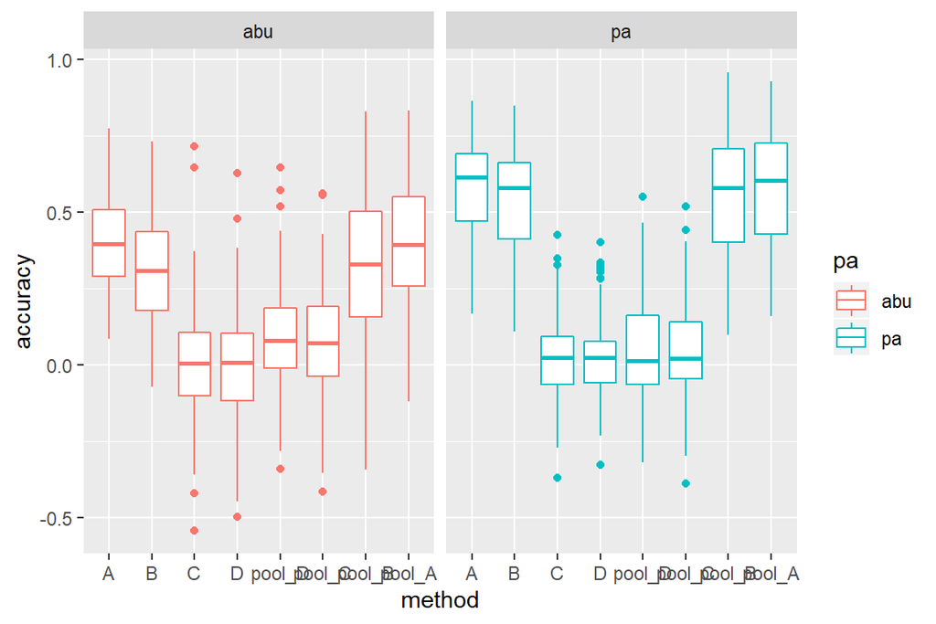

```r
#plottailua
ggplot(res2, aes(x = method, y = accuracy,  colour = pa)) + geom_boxplot() +facet_grid(.~pa)
```

### 3.3.3 Analyysi

Testataan vaikuttaako metodi ja poolaus ennustustarkkuuksiin. Käytän samaa sekamallia kuin aikaisemminkin.(En siis vertaile random-rakenteita enää). Laji on random-muuttuja.

#### aineisto vielä hieman eri muotoon

```r
#aineisto uusiksi, lisään muuttujan 'pool' , joka jakaa tarkkuudet ei-poolattuihin ja poolattuihin
poolres=res2
poolres$pool=NA

poolres$pool[poolres$method=="A"|poolres$method=="B"|poolres$method=="C"|poolres$method=="D"]<-"NPo"
poolres$pool[poolres$method=="pool_A"|poolres$method=="pool_B"|poolres$method=="pool_C"|poolres$method=="pool_D"]<-"Po"
poolres$pool=as.factor(poolres$pool)
poolres$method=stringr::str_replace(poolres$method,'pool_','')
poolres$method=as.factor(poolres$method)

#tarkistellaan taulukkona, tää ei nyt jostain syystä skulaa?!
poolres %>%
  group_by(method, pa, pool) %>%
  summarise(mean = mean(accuracy,na.rm=T),std.errors=std.error(accuracy,na.rm=T))
```

```
## # A tibble: 16 x 5
## # Groups:   method, pa [8]
##    method pa    pool     mean std.errors
##    <fct>  <fct> <fct>   <dbl>      <dbl>
##  1 A      abu   NPo   0.405       0.0149
##  2 A      abu   Po    0.389       0.0199
##  3 A      pa    NPo   0.575       0.0153
##  4 A      pa    Po    0.575       0.0179
##  5 B      abu   NPo   0.313       0.0171
##  6 B      abu   Po    0.327       0.0213
##  7 B      pa    NPo   0.536       0.0164
##  8 B      pa    Po    0.551       0.0187
##  9 C      abu   NPo   0.0120      0.0170
## 10 C      abu   Po    0.0769      0.0164
## 11 C      pa    NPo   0.0232      0.0128
## 12 C      pa    Po    0.0381      0.0150
## 13 D      abu   NPo   0.00270     0.0165
## 14 D      abu   Po    0.0851      0.0154
## 15 D      pa    NPo   0.0239      0.0123
## 16 D      pa    Po    0.0419      0.0152
```

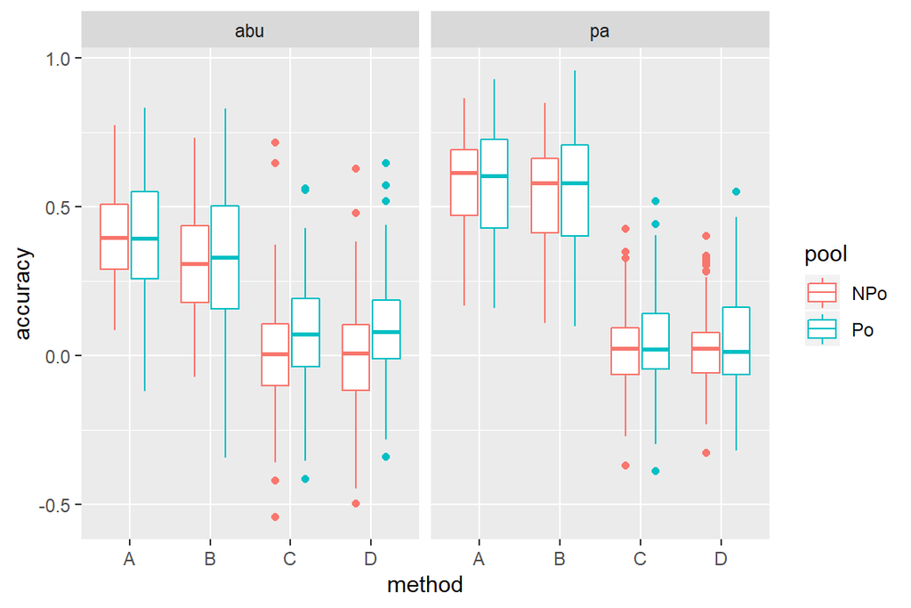

```r
#plottailua
ggplot(poolres,aes(x=method,y=accuracy,color=pool))+geom_boxplot()+facet_grid(.~pa)
```

```r
#tallenna
write.csv(poolres, "poolres.csv",row.names = F)
```

Analysoidaan pa ja abu datasetit erillään:

#### Pa-aineisto:

```r
#jaetaan aineisto pa ja abu aineistoihin
poolresPA=subset(poolres,pa=="pa")
poolresABU=subset(poolres,pa=="abu")
```

```r
#luetaan aineisto sisään, Multiphylo eli monta puuta
linnut <- read.nexus("output.nex")
#valitaan vain yksi puu, mikä tahansa sadasta
linnut2<-linnut[[99]]
#tehdään puusta malliin sopiva fylogeniarakenne
bm.birds<-inverseA(linnut2)$Ainv
```

```r
M1<- MCMCglmm(accuracy ~ method * pool, random=~species, data = poolresPA,family="gaussian",  ginverse=list(species=bm.birds),nitt=1003000, burnin=3000, thin=1000)

M2<- MCMCglmm(accuracy ~ method + pool, random=~species, data = poolresPA,family="gaussian",  ginverse=list(species=bm.birds),nitt=1003000, burnin=3000, thin=1000)

M3<- MCMCglmm(accuracy ~ method, random=~species, data = poolresPA,family="gaussian",  ginverse=list(species=bm.birds),nitt=1003000, burnin=3000, thin=1000)

M4<- MCMCglmm(accuracy ~ pool, random=~species, data = poolresPA,family="gaussian",  ginverse=list(species=bm.birds),nitt=1003000, burnin=3000, thin=1000)
```

```r
output1=model.sel(M1,M2,M3,M4)
output1
```

```
## Model selection table
##     (Int) mth pol mth:pol df   logLik    AICc   delta weight
## M3 0.5275   +              6  619.807 -1227.5    0.00  0.621
## M2 0.5184   +   +          7  620.301 -1226.5    1.04  0.369
## M1 0.5295   +   +       + 10  619.684 -1219.1    8.39  0.009
## M4 0.2698       +          4 -242.997   494.0 1721.56  0.000
## Models ranked by AICc(x)
## Random terms (all models):
## '~species'
```

```r
summary(M3)
```

```
##
##  Iterations = 3001:1002001
##  Thinning interval  = 1000
##  Sample size  = 1000
##
##  DIC: -1137.791
##
##  G-structure:  ~species
##
##         post.mean l-95% CI u-95% CI eff.samp
## species   0.06073  0.04208   0.0831     1000
##
##  R-structure:  ~units
##
##       post.mean l-95% CI u-95% CI eff.samp
## units   0.01613  0.01459  0.01775    896.3
##
##  Location effects: accuracy ~ method
##
##             post.mean  l-95% CI  u-95% CI eff.samp  pMCMC
## (Intercept)  0.527542  0.351616  0.724315     1000 <0.001 ***
## methodB     -0.031707 -0.051931 -0.008329     1000  0.004 **
## methodC     -0.544602 -0.568580 -0.523239     1000 <0.001 ***
## methodD     -0.542449 -0.562876 -0.517498     1000 <0.001 ***
## ---
## Signif. codes:  0 '***' 0.001 '**' 0.01 '*' 0.05 '.' 0.1 ' ' 1
```

```r
summary(M2)
```

```
##
##  Iterations = 3001:1002001
##  Thinning interval  = 1000
##  Sample size  = 1000
##
##  DIC: -1138.174
##
##  G-structure:  ~species
##
##         post.mean l-95% CI u-95% CI eff.samp
## species   0.06048  0.04008  0.08417     1000
##
##  R-structure:  ~units
##
##       post.mean l-95% CI u-95% CI eff.samp
## units    0.0161  0.01476   0.0177     1000
##
##  Location effects: accuracy ~ method + pool
##
##             post.mean  l-95% CI  u-95% CI eff.samp  pMCMC
## (Intercept)  0.518426  0.312324  0.693324     1223 <0.001 ***
## methodB     -0.032094 -0.054313 -0.009837      983 <0.001 ***
## methodC     -0.544572 -0.568639 -0.521046     1030 <0.001 ***
## methodD     -0.542446 -0.566377 -0.519797     1000 <0.001 ***
## poolPo       0.011500 -0.002781  0.027863     1000   0.16
## ---
## Signif. codes:  0 '***' 0.001 '**' 0.01 '*' 0.05 '.' 0.1 ' ' 1
```

```r
#vanhalla tyylillä ilman fylogeniaa
A1=lme(accuracy~method*pool,data=poolresPA,random=~1|species,method="ML",na.action="na.exclude")
A2=lme(accuracy~method+pool,data=poolresPA,random=~1|species,method="ML",na.action="na.exclude")
A3=lme(accuracy~method,data=poolresPA,random=~1|species,method="ML",na.action="na.exclude")
A4=lme(accuracy~pool,data=poolresPA,random=~1|species,method="ML",na.action="na.exclude")

anova(A1,A2)
```

```
##    Model df       AIC       BIC   logLik   Test   L.Ratio p-value
## A1     1 10 -1000.457 -951.7875 510.2284
## A2     2  7 -1005.674 -971.6052 509.8369 1 vs 2 0.7831145  0.8535
```

```r
AIC(A1,A2,A3,A4)
```

```
##    df        AIC
## A1 10 -1000.4569
## A2  7 -1005.6737
## A3  6 -1005.4586
## A4  4   504.8985
```

```r
anova(A2,A3)
```

```
##    Model df       AIC       BIC   logLik   Test  L.Ratio p-value
## A2     1  7 -1005.674 -971.6052 509.8369
## A3     2  6 -1005.459 -976.2570 508.7293 1 vs 2 2.215102  0.1367
```

```r
summary(A3)
```

```
## Linear mixed-effects model fit by maximum likelihood
##  Data: poolresPA
##         AIC      BIC   logLik
##   -1005.459 -976.257 508.7293
##
## Random effects:
##  Formula: ~1 | species
##         (Intercept)  Residual
## StdDev:   0.1153815 0.1252899
##
## Fixed effects: accuracy ~ method
##                  Value  Std.Error  DF   t-value p-value
## (Intercept)  0.5748204 0.01330734 837  43.19575   0.000
## methodB     -0.0315642 0.01146126 837  -2.75399   0.006
## methodC     -0.5441671 0.01146126 837 -47.47884   0.000
## methodD     -0.5419361 0.01146126 837 -47.28418   0.000
##  Correlation:
##         (Intr) methdB methdC
## methodB -0.431
## methodC -0.431  0.500
## methodD -0.431  0.500  0.500
##
## Standardized Within-Group Residuals:
##         Min          Q1         Med          Q3         Max
## -3.10056557 -0.61373098  0.06172161  0.62588292  3.41229002
##
## Number of Observations: 960
## Number of Groups: 120
```

```r
anova(A3)
```

```
##             numDF denDF   F-value p-value
## (Intercept)     1   837  682.6771  <.0001
## method          3   837 1413.4844  <.0001
```

```r
#lopullinen malli
mfinal=lme(accuracy~method,data=poolresPA,random=~1|species,method="REML",na.action="na.exclude")
summary(mfinal)
```

```
## Linear mixed-effects model fit by REML
##  Data: poolresPA
##         AIC       BIC   logLik
##   -976.3323 -947.1558 494.1661
##
## Random effects:
##  Formula: ~1 | species
##         (Intercept)  Residual
## StdDev:   0.1159061 0.1255142
##
## Fixed effects: accuracy ~ method
##                  Value  Std.Error  DF   t-value p-value
## (Intercept)  0.5748204 0.01332640 837  43.13397   0.000
## methodB     -0.0315642 0.01145783 837  -2.75482   0.006
## methodC     -0.5441671 0.01145783 837 -47.49303   0.000
## methodD     -0.5419361 0.01145783 837 -47.29831   0.000
##  Correlation:
##         (Intr) methdB methdC
## methodB -0.43
## methodC -0.43   0.50
## methodD -0.43   0.50   0.50
##
## Standardized Within-Group Residuals:
##         Min          Q1         Med          Q3         Max
## -3.09495180 -0.61252190  0.06172091  0.62455600  3.40626329
##
## Number of Observations: 960
## Number of Groups: 120
```

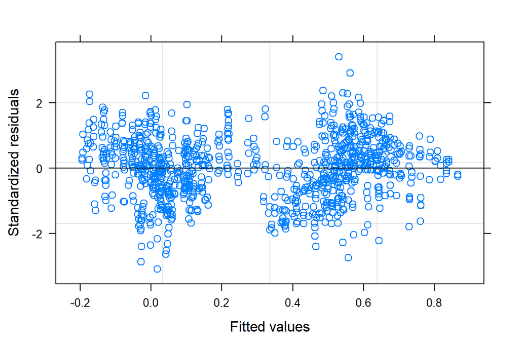

```r
#validointi
plot(mfinal)
```

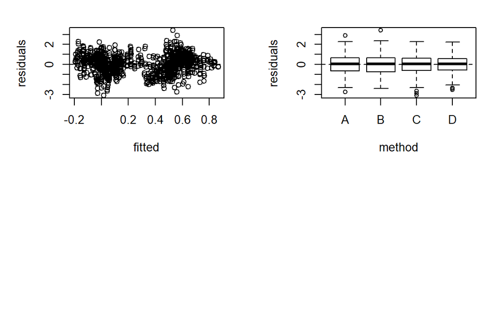

```r
E1=resid(mfinal, type="normalized")
F1=fitted(mfinal)

par(mfrow=c(2,2), mar=c(5,5,2,2))
plot(x=F1,y=E1,xlab="fitted",ylab="residuals")
abline(h=0,lty=2)
boxplot(E1~method,xlab="method",ylab="residuals",data=poolresPA)
abline(h=0,lty=2)
par(mfrow=c(1,1), mar=c(5,5,2,2))
```

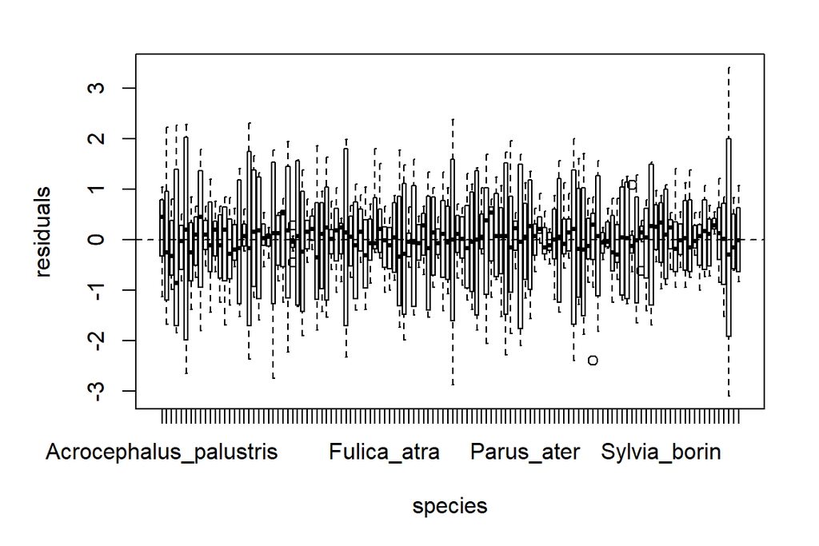

```r
boxplot(E1~species,xlab="species",ylab="residuals",data=poolresPA)
abline(h=0,lty=2)
```

Eli pa-aineistolla vain metodilla on väliä, ei niinkään poolauksella?

#### Abu-aineisto:

```r
N1<- MCMCglmm(accuracy ~ method * pool, random=~species, data = poolresABU,family="gaussian",  ginverse=list(species=bm.birds),nitt=1003000, burnin=3000, thin=1000)

N2<- MCMCglmm(accuracy ~ method + pool, random=~species, data = poolresABU,family="gaussian",  ginverse=list(species=bm.birds),nitt=1003000, burnin=3000, thin=1000)

N3<- MCMCglmm(accuracy ~ method, random=~species, data = poolresABU,family="gaussian",  ginverse=list(species=bm.birds),nitt=1003000, burnin=3000, thin=1000)

N4<- MCMCglmm(accuracy ~ pool, random=~species, data = poolresABU,family="gaussian",  ginverse=list(species=bm.birds),nitt=1003000, burnin=3000, thin=1000)
```

```r
output2=model.sel(N1,N2,N3,N4)
output2
```

```
## Model selection table
##     (Int) mth pol mth:pol df  logLik   AICc  delta weight
## N1 0.3785   +   +       + 10 423.844 -827.5   0.00  0.994
## N2 0.3563   +   +          7 415.725 -817.3  10.12  0.006
## N3 0.3694   +              6 409.272 -806.5  21.00  0.000
## N4 0.1627       +          4  25.816  -43.6 783.87  0.000
## Models ranked by AICc(x)
## Random terms (all models):
## '~species'
```

```r
summary(N1)
```

```
##
##  Iterations = 3001:1002001
##  Thinning interval  = 1000
##  Sample size  = 1000
##
##  DIC: -749.082
##
##  G-structure:  ~species
##
##         post.mean l-95% CI u-95% CI eff.samp
## species   0.05776  0.03569   0.0821     1000
##
##  R-structure:  ~units
##
##       post.mean l-95% CI u-95% CI eff.samp
## units   0.02403  0.02172  0.02645     1105
##
##  Location effects: accuracy ~ method * pool
##
##                post.mean l-95% CI u-95% CI eff.samp  pMCMC
## (Intercept)      0.37847  0.18249  0.56680   1000.0  0.002 **
## methodB         -0.09277 -0.13242 -0.05117   1000.0 <0.001 ***
## methodC         -0.39456 -0.43458 -0.35612   1095.0 <0.001 ***
## methodD         -0.40509 -0.44258 -0.36582   1000.0 <0.001 ***
## poolPo          -0.01606 -0.05430  0.02325   1000.0  0.430
## methodB:poolPo   0.03096 -0.01985  0.09126    902.7  0.248
## methodC:poolPo   0.08123  0.02884  0.14188   1000.0  0.006 **
## methodD:poolPo   0.09915  0.04760  0.15138   1087.4  0.002 **
## ---
## Signif. codes:  0 '***' 0.001 '**' 0.01 '*' 0.05 '.' 0.1 ' ' 1
```

```r
#fixed osan vertailua, abu aineisto:
A1=lme(accuracy~method*pool,data=poolresABU,random=~1|species,method="ML",na.action="na.exclude")
A2=lme(accuracy~method+pool,data=poolresABU,random=~1|species,method="ML",na.action="na.exclude")
A3=lme(accuracy~method,data=poolresABU,random=~1|species,method="ML",na.action="na.exclude")
A4=lme(accuracy~pool,data=poolresABU,random=~1|species,method="ML",na.action="na.exclude")

anova(A1,A2)
```

```
##    Model df       AIC       BIC   logLik   Test  L.Ratio p-value
## A1     1 10 -671.1029 -622.5172 345.5514
## A2     2  7 -661.0587 -627.0487 337.5293 1 vs 2 16.04419  0.0011
```

```r
AIC(A1,A2,A3,A4)
```

```
##    df        AIC
## A1 10 -671.10286
## A2  7 -661.05868
## A3  6 -649.81738
## A4  4   10.07426
```

```r
summary(A1)
```

```
## Linear mixed-effects model fit by maximum likelihood
##  Data: poolresABU
##         AIC       BIC   logLik
##   -671.1029 -622.5172 345.5514
##
## Random effects:
##  Formula: ~1 | species
##         (Intercept)  Residual
## StdDev:   0.1155263 0.1509358
##
## Fixed effects: accuracy ~ method * pool
##                     Value  Std.Error  DF    t-value p-value
## (Intercept)     0.4054711 0.01742462 825  23.270009  0.0000
## methodB        -0.0926735 0.01956812 825  -4.735945  0.0000
## methodC        -0.3949418 0.01966532 825 -20.083161  0.0000
## methodD        -0.4042327 0.01966532 825 -20.555610  0.0000
## poolPo         -0.0164656 0.01956812 825  -0.841449  0.4003
## methodB:poolPo  0.0311646 0.02767350 825   1.126154  0.2604
## methodC:poolPo  0.0813997 0.02779051 825   2.929046  0.0035
## methodD:poolPo  0.0989141 0.02779051 825   3.559278  0.0004
##  Correlation:
##                (Intr) methdB methdC methdD poolPo mthB:P mthC:P
## methodB        -0.562
## methodC        -0.559  0.498
## methodD        -0.559  0.498  0.497
## poolPo         -0.562  0.500  0.498  0.498
## methodB:poolPo  0.397 -0.707 -0.352 -0.352 -0.707
## methodC:poolPo  0.395 -0.352 -0.707 -0.350 -0.704  0.498
## methodD:poolPo  0.395 -0.352 -0.350 -0.707 -0.704  0.498  0.496
##
## Standardized Within-Group Residuals:
##         Min          Q1         Med          Q3         Max
## -3.72376831 -0.60598997 -0.02468816  0.65012422  4.05501422
##
## Number of Observations: 952
## Number of Groups: 120
```

```r
anova(A1)
```

```
##             numDF denDF  F-value p-value
## (Intercept)     1   825 301.9128  <.0001
## method          3   825 353.0350  <.0001
## pool            1   825  13.4933  0.0003
## method:pool     3   825   5.3547  0.0012
```

Mutta abu aineistolla sekä metodilla että poolauksella yhdessä on vaikutusta?

```r
#lopullinen malli
mfinal=lme(accuracy~method*pool,data=poolresABU,random=~1|species,method="REML",na.action="na.exclude")
summary(mfinal)
```

```
## Linear mixed-effects model fit by REML
##  Data: poolresABU
##         AIC       BIC   logLik
##   -619.0906 -570.5893 319.5453
##
## Random effects:
##  Formula: ~1 | species
##         (Intercept)  Residual
## StdDev:   0.1160111 0.1515745
##
## Fixed effects: accuracy ~ method * pool
##                     Value  Std.Error  DF    t-value p-value
## (Intercept)     0.4054711 0.01742446 825  23.270224  0.0000
## methodB        -0.0926735 0.01956819 825  -4.735928  0.0000
## methodC        -0.3949418 0.01966539 825 -20.083087  0.0000
## methodD        -0.4042326 0.01966539 825 -20.555534  0.0000
## poolPo         -0.0164656 0.01956819 825  -0.841446  0.4003
## methodB:poolPo  0.0311646 0.02767360 825   1.126150  0.2604
## methodC:poolPo  0.0813997 0.02779061 825   2.929035  0.0035
## methodD:poolPo  0.0989141 0.02779061 825   3.559265  0.0004
##  Correlation:
##                (Intr) methdB methdC methdD poolPo mthB:P mthC:P
## methodB        -0.562
## methodC        -0.559  0.498
## methodD        -0.559  0.498  0.497
## poolPo         -0.562  0.500  0.498  0.498
## methodB:poolPo  0.397 -0.707 -0.352 -0.352 -0.707
## methodC:poolPo  0.395 -0.352 -0.707 -0.350 -0.704  0.498
## methodD:poolPo  0.395 -0.352 -0.350 -0.707 -0.704  0.498  0.496
##
## Standardized Within-Group Residuals:
##         Min          Q1         Med          Q3         Max
## -3.70807071 -0.60342768 -0.02458745  0.64737954  4.03792763
##
## Number of Observations: 952
## Number of Groups: 120
```

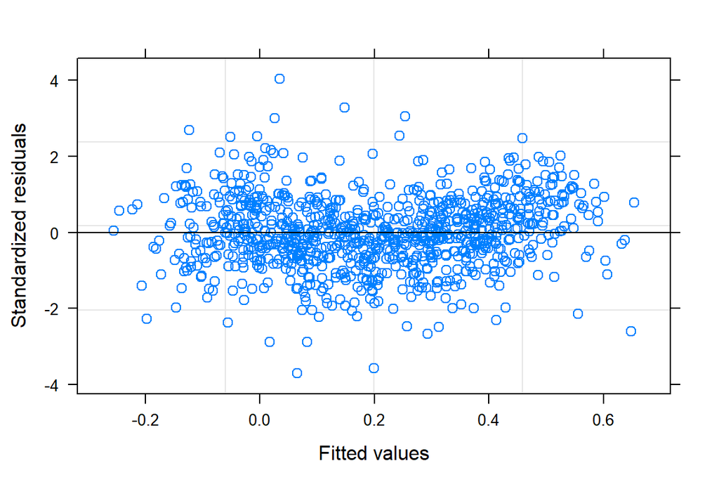

```r
#validointi
plot(mfinal)
```

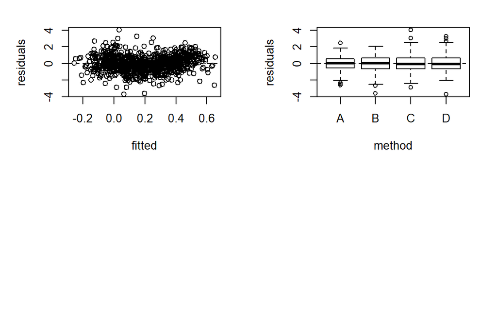

```r
E1=resid(mfinal, type="normalized")
F1=fitted(mfinal)

par(mfrow=c(2,2), mar=c(5,5,2,2))
plot(x=F1,y=E1,xlab="fitted",ylab="residuals")
abline(h=0,lty=2)
boxplot(E1~method,xlab="method",ylab="residuals",data=poolresABU)
abline(h=0,lty=2)
par(mfrow=c(1,1), mar=c(5,5,2,2))
```

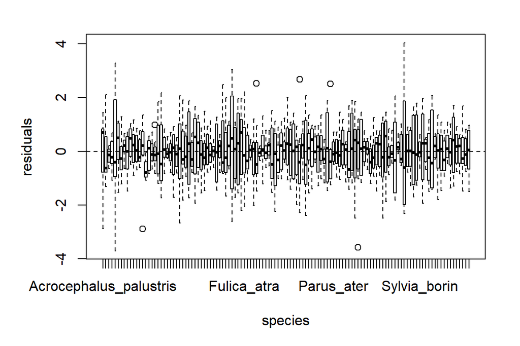

```r
boxplot(E1~species,xlab="species",ylab="residuals",data=poolresABU)
abline(h=0,lty=2)
```

Abu-aineistolla sekä metodilla että poolauksella, ja niiden yhteisvaikutuksella on väliä.

### 3.3.5 Luottamusvälit

```r
stat <- summarySE(poolres, measurevar="accuracy", groupvars=c("method","pa","pool"),na.rm = T)
stat
```

```
##    method  pa pool   N    accuracy        sd         se         ci
## 1       A abu  NPo 120 0.405471135 0.1628117 0.01486261 0.02942945
## 2       A abu   Po 120 0.389005553 0.2183761 0.01993492 0.03947313
## 3       A  pa  NPo 120 0.574904752 0.1676330 0.01530273 0.03030093
## 4       A  pa   Po 120 0.574736004 0.1962630 0.01791627 0.03547601
## 5       B abu  NPo 120 0.312797596 0.1870312 0.01707354 0.03380731
## 6       B abu   Po 120 0.327496642 0.2331769 0.02128604 0.04214848
## 7       B  pa  NPo 120 0.535540286 0.1797158 0.01640573 0.03248499
## 8       B  pa   Po 120 0.550972018 0.2051344 0.01872612 0.03707959
## 9       C abu  NPo 118 0.011986434 0.1850550 0.01703570 0.03373830
## 10      C abu   Po 118 0.076920534 0.1778541 0.01637280 0.03242548
## 11      C  pa  NPo 120 0.023247787 0.1398196 0.01276373 0.02527346
## 12      C  pa   Po 120 0.038058772 0.1645565 0.01502188 0.02974483
## 13      D abu  NPo 118 0.002695576 0.1797458 0.01654694 0.03277035
## 14      D abu   Po 118 0.085144143 0.1670662 0.01537969 0.03045867
## 15      D  pa  NPo 120 0.023863762 0.1345628 0.01228385 0.02432325
## 16      D  pa   Po 120 0.041904857 0.1670504 0.01524954 0.03019562
```

```r
stat$lower=stat$accuracy-stat$ci
stat$upper=stat$accuracy+stat$ci
#names(stat)[2] <- "Data_type"
#names(stat)[3] <- "Spatial_scale"
#stat$pool=revalue(stat$pool, c("NPo"="non-pooled", "Po"="pooled"))
knitr::kable(stat)
```

| method | pa | pool | N | accuracy | sd | se | ci | lower | upper |
| --- | --- | --- | --- | --- | --- | --- | --- | --- | --- |
| A | abu | NPo | 120 | 0.4054711 | 0.1628117 | 0.0148626 | 0.0294295 | 0.3760417 | 0.4349006 |
| A | abu | Po | 120 | 0.3890056 | 0.2183761 | 0.0199349 | 0.0394731 | 0.3495324 | 0.4284787 |
| A | pa | NPo | 120 | 0.5749048 | 0.1676330 | 0.0153027 | 0.0303009 | 0.5446038 | 0.6052057 |
| A | pa | Po | 120 | 0.5747360 | 0.1962630 | 0.0179163 | 0.0354760 | 0.5392600 | 0.6102120 |
| B | abu | NPo | 120 | 0.3127976 | 0.1870312 | 0.0170735 | 0.0338073 | 0.2789903 | 0.3466049 |
| B | abu | Po | 120 | 0.3274966 | 0.2331769 | 0.0212860 | 0.0421485 | 0.2853482 | 0.3696451 |
| B | pa | NPo | 120 | 0.5355403 | 0.1797158 | 0.0164057 | 0.0324850 | 0.5030553 | 0.5680253 |
| B | pa | Po | 120 | 0.5509720 | 0.2051344 | 0.0187261 | 0.0370796 | 0.5138924 | 0.5880516 |
| C | abu | NPo | 118 | 0.0119864 | 0.1850550 | 0.0170357 | 0.0337383 | -0.0217519 | 0.0457247 |
| C | abu | Po | 118 | 0.0769205 | 0.1778541 | 0.0163728 | 0.0324255 | 0.0444951 | 0.1093460 |
| C | pa | NPo | 120 | 0.0232478 | 0.1398196 | 0.0127637 | 0.0252735 | -0.0020257 | 0.0485212 |
| C | pa | Po | 120 | 0.0380588 | 0.1645565 | 0.0150219 | 0.0297448 | 0.0083139 | 0.0678036 |
| D | abu | NPo | 118 | 0.0026956 | 0.1797458 | 0.0165469 | 0.0327704 | -0.0300748 | 0.0354659 |
| D | abu | Po | 118 | 0.0851441 | 0.1670662 | 0.0153797 | 0.0304587 | 0.0546855 | 0.1156028 |
| D | pa | NPo | 120 | 0.0238638 | 0.1345628 | 0.0122838 | 0.0243232 | -0.0004595 | 0.0481870 |
| D | pa | Po | 120 | 0.0419049 | 0.1670504 | 0.0152495 | 0.0301956 | 0.0117092 | 0.0721005 |

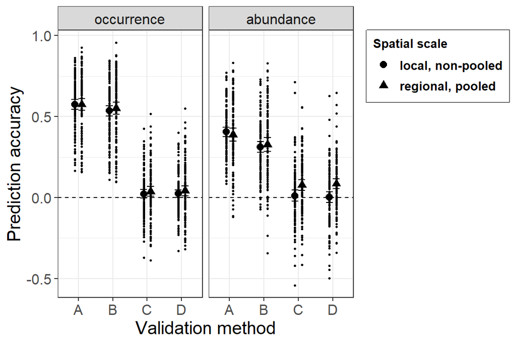

```r
#names(res2)[4] <- "Data_type"

pd <- position_dodge(0.4) # move them .05 to the left and right
# Black error bars - notice the mapping of 'group=supp' -- without it, the error
# bars won't be dodged!
poolres$pa=revalue(poolres$pa, c("pa"="occurrence", "abu"="abundance"))
stat$pa=revalue(stat$pa, c("pa"="occurrence", "abu"="abundance"))
stat$pool=revalue(stat$pool, c("NPo"="local, non-pooled", "Po"="regional, pooled"))

stat$pa=factor(stat$pa, levels=c("occurrence","abundance"))

ggplot(stat, aes(y=accuracy, x=method, group=pool)) +
  geom_point(aes(shape=pool),position=pd,size=2.5)  +
  scale_shape_manual(values=c(19,17),name = "Spatial scale") +
  geom_errorbar(aes(ymin=accuracy-ci, ymax=accuracy+ci), colour="black", width=.4, position=pd) +
  ylab("Prediction accuracy") +
  xlab("Validation method") +
  theme_bw() +
  theme(legend.justification=c(1,1),
          legend.box.background=element_rect()) +
  theme(text = element_text(size = 15)) +
  geom_point(data=poolres,position=pd, size=0.5) +
  facet_grid(.~pa) +
  geom_hline(yintercept = 0, linetype="dashed") +
  theme(legend.title = element_text(colour="black", size=10,
                                      face="bold")) +
  theme(legend.text = element_text(colour="black", size=10,
                                     face="bold"))
```

```r
ggsave("plot3_pa_pool_method.png")
```

# 4. Traits analyysi

Selvitetään ovatko tietyt lajiominaisuudet kytköksissä ennustustarkkuuteen.  
Analysoin pa ja abu-aineistot erillään.

## 4.1 Aineisto sisään ja taulukoiden kokoaminen

Log-muunnetaan prevalenssi ja massa.

```r
#aineiston valinta, leväyttäminen ja uudelleen nimeäminen
poolres<-read.csv("poolres.csv")

#lisätään lajiominaisuudet taulukkoon
traits<-read.csv("traits_table.csv",sep = ";")
results<-inner_join(poolres,traits,by="species")
str(results)
```

```
## 'data.frame':    1920 obs. of  9 variables:
##  $ species : chr  "Acrocephalus_palustris" "Acrocephalus_schoenobaenus" "Acrocephalus_scirpaceus" "Actitis_hypoleucos" ...
##  $ method  : Factor w/ 4 levels "A","B","C","D": 1 1 1 1 1 1 1 1 1 1 ...
##  $ accuracy: num  0.525 0.232 0.316 0.292 0.402 ...
##  $ pa      : Factor w/ 2 levels "abu","pa": 1 1 1 1 1 1 1 1 1 1 ...
##  $ pool    : Factor w/ 2 levels "NPo","Po": 1 1 1 1 1 1 1 1 1 1 ...
##  $ Mig     : Factor w/ 3 levels "L","R","S": 1 1 1 1 2 3 3 3 3 3 ...
##  $ Hab     : Factor w/ 4 levels "CU","FO","MM",..: 4 4 4 4 2 1 4 4 4 3 ...
##  $ Mass    : num  12 12 13 47.5 8 ...
##  $ Prev    : num  0.0818 0.1246 0.1479 0.3026 0.1321 ...
```

```r
results$species=as.factor(results$species)

#uusi muuttuja, massan logaritmi
results$logmass<-log(results$Mass)

#uusi muuttuja, log-muunnettu prevalenssi
results$PrevS=log(results$Prev)

#arcsin-muunnos (kokeiltu)
#asinTransform <- function(p) { asin(sqrt(p)) }
#results$PrevS=asinTransform(results$Prev)

#logit-muunnos (kokeilin, antaa ihan samanlaiset residuaalit)
#logitTransform <- function(p) { log(p/(1-p)) }
#results$PrevS=logitTransform(results$Prev)

#tallenna tarvittaessa omaksi taulukokseen
#write.csv(results,"accuracies_traits.csv",row.names = F)
```

## 4.2 Aineiston tarkastelu

Tarkastellaan aineistoa kuvaajista. Jaetaan aineisto ensin pa ja abu-aineistoihin.

```r
#jaetaan aineisto pa ja abu aineistoihin
resPA=subset(results,pa=="pa")
resABU=subset(results,pa=="abu")
```

*Habitat*

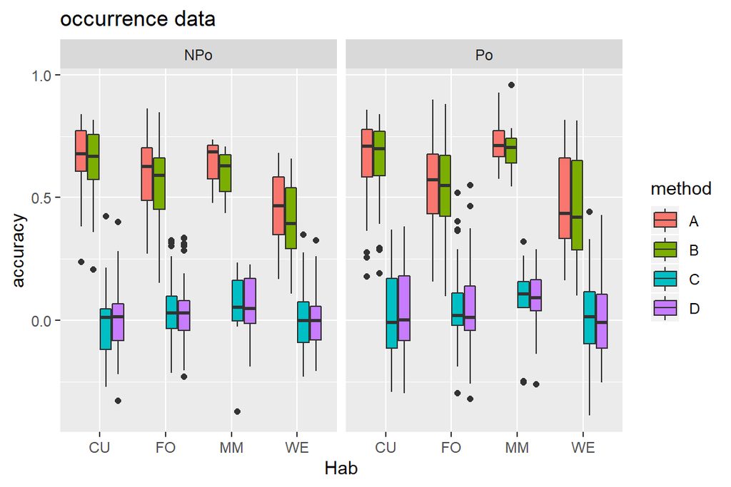

```r
ggplot(resPA, aes(x=Hab, y=accuracy)) +
  geom_boxplot(aes(fill=method)) + facet_grid(. ~pool ) +
  ggtitle("occurrence data")
```

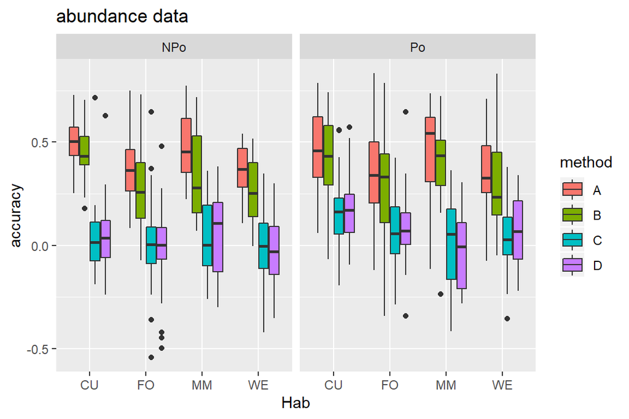

```r
ggplot(resABU, aes(x=Hab, y=accuracy)) +
  geom_boxplot(aes(fill=method)) + facet_grid(. ~pool ) +
  ggtitle("abundance data")
```

*Migration*

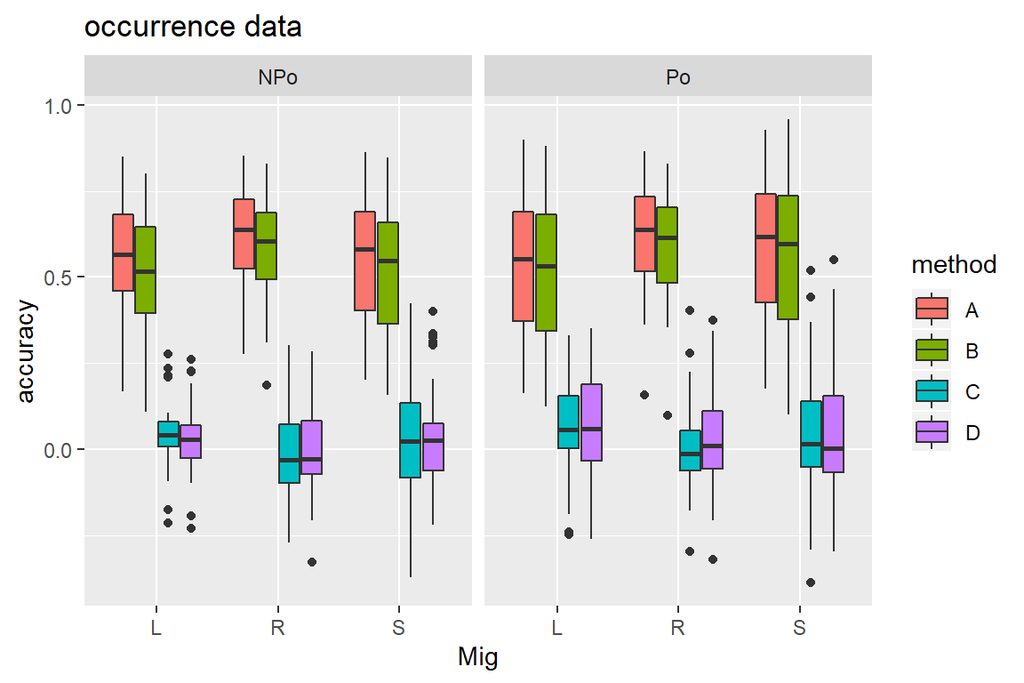

```r
#pa aineisto
ggplot(resPA, aes(x=Mig, y=accuracy)) +
  geom_boxplot(aes(fill=method))+ facet_grid(. ~pool ) +
  ggtitle("occurrence data")
```

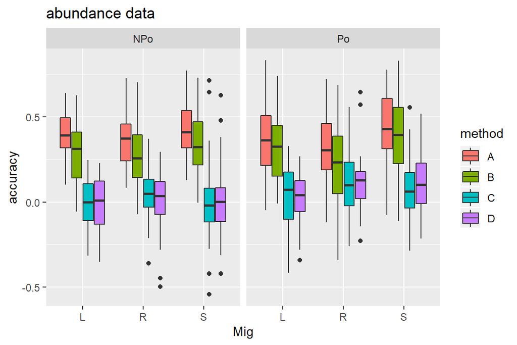

```r
ggplot(resABU, aes(x=Mig, y=accuracy)) +
  geom_boxplot(aes(fill=method))+ facet_grid(. ~pool ) +
  ggtitle("abundance data")
```

*Prevalence*

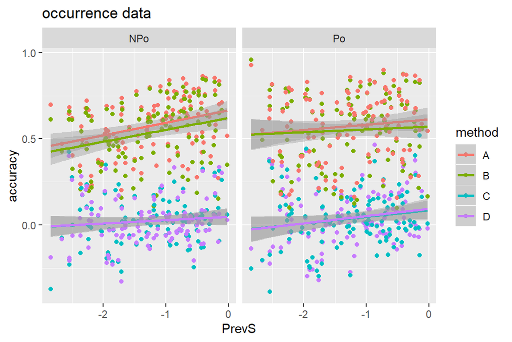

```r
#pa aineisto
ggplot(resPA, aes(x=PrevS, y=accuracy,color=method)) +
  geom_point () +
  geom_smooth(method=lm) +
  ggtitle("occurrence data") +
  facet_grid(. ~pool)
```

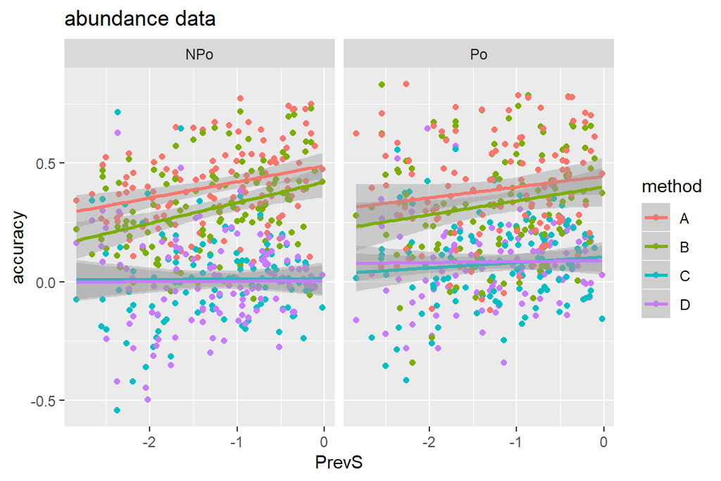

```r
#abu
ggplot(resABU, aes(x=PrevS, y=accuracy,color=method)) +
  geom_point()+
   geom_smooth(method=lm) +
  facet_grid(. ~pool ) +
  ggtitle("abundance data")
```

*Mass*

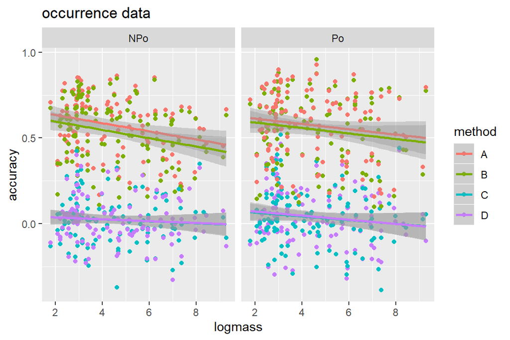

```r
#pa aineisto
ggplot(resPA, aes(x=logmass, y=accuracy,color=method)) +
  geom_point () +
  geom_smooth(method=lm) +
  ggtitle("occurrence data") +
  facet_grid(. ~pool)
```

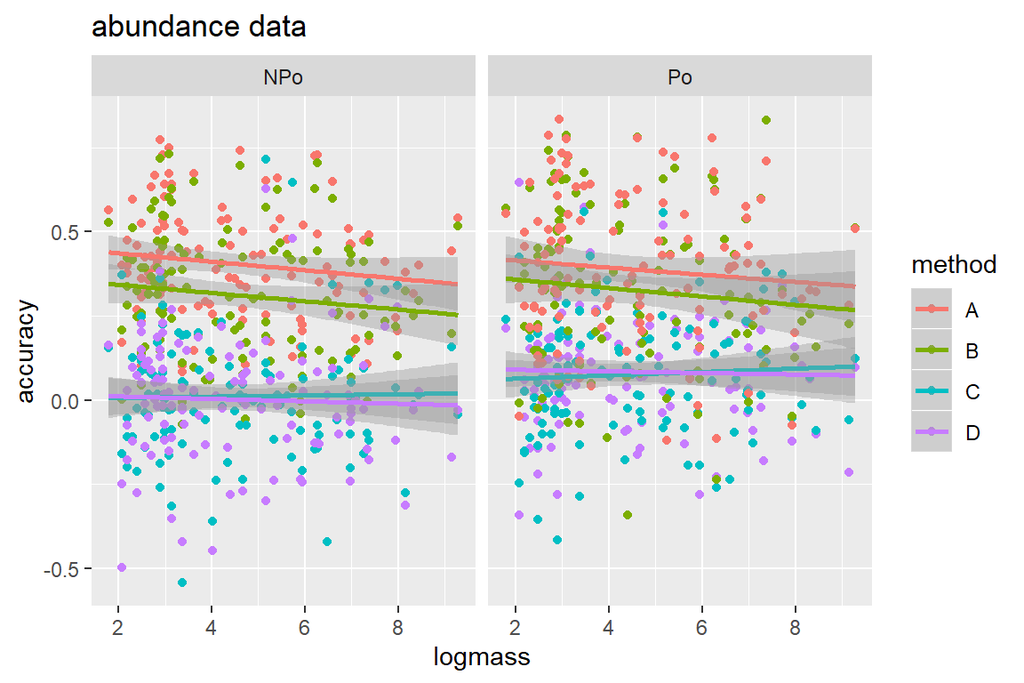

```r
#abu
ggplot(resABU, aes(x=logmass, y=accuracy,color=method)) +
  geom_point()+
   geom_smooth(method=lm) +
  facet_grid(. ~pool ) +
  ggtitle("abundance data")
```

Tarkistan massan ja prevalenssin korrelaation:

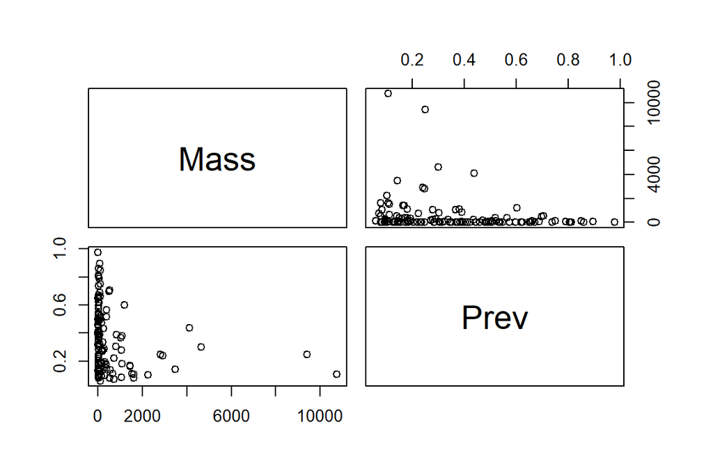

```r
pairs(results[8:9])
```

```r
cor(results$logmass,results$PrevS)
```

```
## [1] -0.3171843
```

Massa ja yleisyys eivät näytä korreloivan suuresti.

## 4.3 Fylogenia

BirdTree.org palvelusta on haettu lintujen sukupuu (tai itseasiassa tiedosto sisältää 100 vaihtoehtoista sukupuuta, joista valitaan yksi).

MCMCglmm-funktio vaatii fylogenian tietyssä rakenteessa:

ginverse= a list of sparse inverse matrices (A−1) that are proportional to the covariance structure of the random effects. The names of the matrices should correspond to columns in data that are associated with the random term. All levels of the random term should appear as rownames for the matrices.

```r
#luetaan aineisto sisään, Multiphylo eli monta puuta
linnut <- read.nexus("output.nex")
#valitaan vain yksi puu, mikä tahansa sadasta
linnut2<-linnut[[99]]
#tehdään puusta malliin sopiva fylogeniarakenne
bm.birds<-inverseA(linnut2)$Ainv
```

## 4.4 Analyysit MCMCglmm

Selvitetään, vaikuttavatko lajien ominaisuudet (muuttokäyttäytyminen ‘Mig’, elinympäristö ‘Hab’, paino ‘logMass’ tai prevalenssi ‘Prev’) ennustustarkkuuteen. Analyysissä pitäisi huomioida fylogenia eli, että lajit voivat olla ominaisuuksiltaan samankaltaisia (ja siten omata myös samanlaiset ennustustarkkuudet) läheisen sukulaisuussuhteen takia. Mukana nyt myös ominaisuuksien mahdolliset yhdysvaikutukset metodin ja poolauksen kanssa.

### 4.4.1 Pa-aineisto

Luodaan mallivaihtoehdot.

```r
#priori
#prior<-list(R=list(V=1, nu=0.00), G=list(G1=list(V=1, nu=0.00))) #mutta tämä ei nyt ole malleissa mukana (?)

#m1<- MCMCglmm(accuracy ~ Hab*method*pool + PrevS*method*pool + Mig*method*pool + logmass*method*pool, random=~species, data = resPA,family="gaussian",ginverse=list(species=bm.birds),nitt=1003000, burnin=3000, thin=1000)

#m2<- MCMCglmm(accuracy ~ Hab*method + Hab*pool +PrevS*method + PrevS*pool + Mig*method + Mig*pool + logmass*method + logmass*pool, random=~ species, data = resPA,family="gaussian",ginverse=list(species=bm.birds),nitt=1003000, burnin=3000, thin=1000)

#m3<- MCMCglmm(accuracy~ Hab*method +PrevS*method + Mig*method + logmass*method + pool, random=~species, data = resPA,family="gaussian",ginverse=list(species=bm.birds),nitt=1003000, burnin=3000, thin=1000)

#m4<- MCMCglmm(accuracy ~ Hab*pool +PrevS*pool + Mig*pool + logmass*pool + method, random=~species, data = resPA,family="gaussian",ginverse=list(species=bm.birds),nitt=1003000, burnin=3000, thin=1000)

#m5<- MCMCglmm(accuracy ~ Hab + PrevS + Mig + logmass + method + pool, random=~species, data = resPA,family="gaussian",ginverse=list(species=bm.birds),nitt=1003000, burnin=3000, thin=1000)

#m6<- MCMCglmm(accuracy ~ Hab*method +PrevS*method + Mig*method  + pool, random=~species, data = resPA,family="gaussian",ginverse=list(species=bm.birds),nitt=1003000, burnin=3000, thin=1000)

#m7<- MCMCglmm(accuracy ~ Hab*method +PrevS*method  + logmass*method + pool, random=~species, data = resPA,family="gaussian",ginverse=list(species=bm.birds),nitt=1003000, burnin=3000, thin=1000)

#m8<- MCMCglmm(accuracy ~ Hab*method + Mig*method + logmass*method + pool, random=~species, data = resPA,family="gaussian",ginverse=list(species=bm.birds),nitt=1003000, burnin=3000, thin=1000)

#m9<- MCMCglmm(accuracy ~ Prev*method + Mig*method + logmass*method + pool, random=~species, data = resPA,family="gaussian",ginverse=list(species=bm.birds),nitt=1003000, burnin=3000, thin=1000)

#m10<- MCMCglmm(accuracy ~ Hab*method +PrevS*method + pool, random=~species, data = resPA,family="gaussian",ginverse=list(species=bm.birds),nitt=1003000, burnin=3000, thin=1000)

#m11<- MCMCglmm(accuracy ~ Hab*method + Mig*method  + pool, random=~species, data = resPA,family="gaussian",ginverse=list(species=bm.birds),nitt=1003000, burnin=3000, thin=1000)

#m12<- MCMCglmm(accuracy ~ Hab*method + logmass*method + pool, random=~species, data=      resPA,family="gaussian",ginverse=list(species=bm.birds),nitt=1003000, burnin=3000, thin=1000)

#m13<- MCMCglmm(accuracy ~ PrevS*method + Mig*method  + pool, random=~species, data = resPA,family="gaussian",ginverse=list(species=bm.birds),nitt=1003000, burnin=3000, thin=1000)

#m14<- MCMCglmm(accuracy ~ PrevS*method +  logmass*method + pool, random=~species, data = resPA,family="gaussian",ginverse=list(species=bm.birds),nitt=1003000, burnin=3000, thin=1000)

#m15<- MCMCglmm(accuracy ~ Mig*method + logmass*method + pool, random=~species, data = resPA,family="gaussian",ginverse=list(species=bm.birds),nitt=1003000, burnin=3000, thin=1000)

#m16<- MCMCglmm(accuracy ~ Hab*method + pool, random=~species, data = resPA,family="gaussian",ginverse=list(species=bm.birds),nitt=1003000, burnin=3000, thin=1000)

#m17<- MCMCglmm(accuracy ~ PrevS*method + pool, random=~species, data = resPA,family="gaussian",ginverse=list(species=bm.birds),nitt=1003000, burnin=3000, thin=1000)

#m18<- MCMCglmm(accuracy ~ Mig*method  + pool, random=~species, data = resPA,family="gaussian",ginverse=list(species=bm.birds),nitt=1003000, burnin=3000, thin=1000)

#m19<- MCMCglmm(accuracy ~ logmass*method + pool, random=~species, data = resPA,family="gaussian",ginverse=list(species=bm.birds),nitt=1003000, burnin=3000, thin=1000)
```

```r
#priori
#prior<-list(R=list(V=1, nu=0.00), G=list(G1=list(V=1, nu=0.00))) #mutta tämä ei nyt ole malleissa mukana (?)

m1<- MCMCglmm(accuracy ~ Hab*method*pool + PrevS*method*pool + Mig*method*pool + logmass*method*pool, random=~species, data = resPA,family="gaussian",ginverse=list(species=bm.birds),nitt=1003000, burnin=3000, thin=1000)

m2<- MCMCglmm(accuracy ~ Hab*method + Hab*pool +PrevS*method + PrevS*pool + Mig*method + Mig*pool + logmass*method + logmass*pool, random=~ species, data = resPA,family="gaussian",ginverse=list(species=bm.birds),nitt=1003000, burnin=3000, thin=1000)

m3<- MCMCglmm(accuracy~ Hab*method +PrevS*method + Mig*method + logmass*method + pool, random=~species, data = resPA,family="gaussian",ginverse=list(species=bm.birds),nitt=1003000, burnin=3000, thin=1000)

m4<- MCMCglmm(accuracy ~ Hab*pool +PrevS*pool + Mig*pool + logmass*pool + method, random=~species, data = resPA,family="gaussian",ginverse=list(species=bm.birds),nitt=1003000, burnin=3000, thin=1000)

m5<- MCMCglmm(accuracy ~ Hab + PrevS + Mig + logmass + method + pool, random=~species, data = resPA,family="gaussian",ginverse=list(species=bm.birds),nitt=1003000, burnin=3000, thin=1000)

m6<- MCMCglmm(accuracy ~ Hab*method +PrevS*method + Mig*method  + pool, random=~species, data = resPA,family="gaussian",ginverse=list(species=bm.birds),nitt=1003000, burnin=3000, thin=1000)

m7<- MCMCglmm(accuracy ~ Hab*method +PrevS*method  + logmass*method + pool, random=~species, data = resPA,family="gaussian",ginverse=list(species=bm.birds),nitt=1003000, burnin=3000, thin=1000)

m8<- MCMCglmm(accuracy ~ Hab*method + Mig*method + logmass*method + pool, random=~species, data = resPA,family="gaussian",ginverse=list(species=bm.birds),nitt=1003000, burnin=3000, thin=1000)

m9<- MCMCglmm(accuracy ~ PrevS*method + Mig*method + logmass*method + pool, random=~species, data = resPA,family="gaussian",ginverse=list(species=bm.birds),nitt=1003000, burnin=3000, thin=1000)

m10<- MCMCglmm(accuracy ~ Hab*method +PrevS*method + pool, random=~species, data = resPA,family="gaussian",ginverse=list(species=bm.birds),nitt=1003000, burnin=3000, thin=1000)

m11<- MCMCglmm(accuracy ~ Hab*method + Mig*method  + pool, random=~species, data =
resPA,family="gaussian",ginverse=list(species=bm.birds),nitt=1003000, burnin=3000, thin=1000)

m12<- MCMCglmm(accuracy ~ Hab*method + logmass*method + pool, random=~species, data=      resPA,family="gaussian",ginverse=list(species=bm.birds),nitt=1003000, burnin=3000, thin=1000)

m13<- MCMCglmm(accuracy ~ PrevS*method + Mig*method  + pool, random=~species, data = resPA,family="gaussian",ginverse=list(species=bm.birds),nitt=1003000, burnin=3000, thin=1000)

m14<- MCMCglmm(accuracy ~ PrevS*method +  logmass*method + pool, random=~species, data = resPA,family="gaussian",ginverse=list(species=bm.birds),nitt=1003000, burnin=3000, thin=1000)

m15<- MCMCglmm(accuracy ~ Mig*method + logmass*method + pool, random=~species, data = resPA,family="gaussian",ginverse=list(species=bm.birds),nitt=1003000, burnin=3000, thin=1000)

m16<- MCMCglmm(accuracy ~ Hab*method + pool, random=~species, data = resPA,family="gaussian",ginverse=list(species=bm.birds),nitt=1003000, burnin=3000, thin=1000)

m17<- MCMCglmm(accuracy ~ PrevS*method + pool, random=~species, data = resPA,family="gaussian",ginverse=list(species=bm.birds),nitt=1003000, burnin=3000, thin=1000)

m18<- MCMCglmm(accuracy ~ Mig*method  + pool, random=~species, data = resPA,family="gaussian",ginverse=list(species=bm.birds),nitt=1003000, burnin=3000, thin=1000)

m19<- MCMCglmm(accuracy ~ logmass*method + pool, random=~species, data = resPA,family="gaussian",ginverse=list(species=bm.birds),nitt=1003000, burnin=3000, thin=1000)
```

Mumin-paketin model.sel näyttää toimivan myös MCMCglmm-tuotoksen kanssa.

```r
#mallin valintaa MuMin paketin avulla
output1<-model.sel(m1,m2,m3,m4,m5,m6,m7,m8,m9,m10,m11,m12,m13,m14,m15,m16,m17,m18,m19)
output1
```

```
## Model selection table
##      (Int) Hab        lgm mth Mig pol     PrS Hab:mth Hab:pol lgm:mth
## m11 0.5862   +              +   +   +               +
## m8  0.5720   + -0.0007030   +   +   +               +               +
## m16 0.6332   +              +       +               +
## m6  0.6223   +              +   +   + 0.03086       +
## m3  0.5969   +  0.0024910   +   +   + 0.03065       +               +
## m10 0.6678   +              +       + 0.02882       +
## m12 0.5942   +  0.0067590   +       +               +               +
## m7  0.6119   +  0.0106600   +       + 0.02949       +               +
## m2  0.5948   +  0.0040210   +   +   + 0.03497       +       +       +
## m15 0.5073     -0.0071040   +   +   +                               +
## m18 0.4916                  +   +   +
## m9  0.5210     -0.0038370   +   +   + 0.01766                       +
## m13 0.5174                  +   +   + 0.02235
## m19 0.5232     -0.0022630   +       +                               +
## m17 0.5534                  +       + 0.02494
## m5  0.5558   +  0.0074330   +   +   + 0.02134
## m14 0.5520      0.0002712   +       + 0.02171                       +
## m4  0.5524   +  0.0101300   +   +   + 0.02597               +
## m1  0.6330   +  0.0035070   +   +   + 0.04605       +       +       +
##     lgm:pol mth:Mig mth:pol mth:PrS Mig:pol pol:PrS Hab:mth:pol
## m11               +
## m8                +
## m16
## m6                +               +
## m3                +               +
## m10                               +
## m12
## m7                                +
## m2        +       +               +       +       +
## m15               +
## m18               +
## m9                +               +
## m13               +               +
## m19
## m17                               +
## m5
## m14                               +
## m4        +                               +       +
```

[output cut: 9 more lines]

```
## m7                                      27 654.673 -1253.7 30.30  0.000
## m2                                      42 669.397 -1250.9 33.16  0.000
## m15                                     19 643.296 -1247.8 36.24  0.000
## m18                                     15 635.614 -1240.7 43.30  0.000
## m9                                      23 641.173 -1235.2 48.85  0.000
## m13                                     19 635.685 -1232.6 51.46  0.000
## m19                                     11 623.201 -1224.1 59.90  0.000
## m17                                     11 620.910 -1219.5 64.48  0.000
## m5                                      14 621.128 -1213.8 70.21  0.000
## m14                                     15 621.953 -1213.4 70.62  0.000
## m4                                      21 620.253 -1197.5 86.50  0.000
## m1            +           +           + 66 663.387 -1184.9 99.15  0.000
## Models ranked by AICc(x)
## Random terms (all models):
## '~species'
```

Malli 11, accuracy ~ Hab x method + Mig x method + pool, on näistä paras. Seuraavaksi paras malli sisältää myös painon ja metodin interaktion.

Malli 11 näyttää tältä:

```r
summary(m11)
```

```
##
##  Iterations = 3001:1002001
##  Thinning interval  = 1000
##  Sample size  = 1000
##
##  DIC: -1220.266
##
##  G-structure:  ~species
##
##         post.mean l-95% CI u-95% CI eff.samp
## species   0.05568  0.03687  0.07491     1000
##
##  R-structure:  ~units
##
##       post.mean l-95% CI u-95% CI eff.samp
## units   0.01445  0.01311  0.01585     1000
##
##  Location effects: accuracy ~ Hab * method + Mig * method + pool
##
##               post.mean  l-95% CI  u-95% CI eff.samp  pMCMC
## (Intercept)    0.586244  0.360406  0.785002   1000.0 <0.001 ***
## HabFO         -0.098409 -0.162610 -0.031492   1000.0  0.006 **
## HabMM          0.058544 -0.033478  0.151755   1000.0  0.240
## HabWE         -0.217153 -0.308672 -0.119069    902.3 <0.001 ***
## methodB       -0.020384 -0.080250  0.042100    786.6  0.516
## methodC       -0.569774 -0.636274 -0.511079    692.6 <0.001 ***
## methodD       -0.569095 -0.638599 -0.509986   1000.0 <0.001 ***
## MigR           0.041773 -0.050567  0.127418   1000.0  0.366
## MigS           0.080757  0.006376  0.149618   1000.0  0.034 *
## poolPo         0.012331 -0.002647  0.028036   1000.0  0.106
## HabFO:methodB -0.020894 -0.082086  0.038795   1000.0  0.490
## HabMM:methodB -0.012152 -0.117963  0.067506   1000.0  0.814
## HabWE:methodB -0.016106 -0.091246  0.044768    936.5  0.652
## HabFO:methodC  0.102205  0.046113  0.160418   1000.0  0.002 **
## HabMM:methodC -0.021393 -0.108640  0.067631   1000.0  0.648
## HabWE:methodC  0.174756  0.108542  0.246402    912.2 <0.001 ***
## HabFO:methodD  0.086638  0.032642  0.148563   1000.0  0.012 *
## HabMM:methodD -0.018897 -0.107541  0.067595   1000.0  0.678
## HabWE:methodD  0.159165  0.091276  0.228435   1000.0 <0.001 ***
## methodB:MigR   0.008103 -0.053946  0.062750   1000.0  0.774
## methodC:MigR  -0.114934 -0.172313 -0.055518   1000.0 <0.001 ***
## methodD:MigR  -0.089705 -0.151003 -0.028220   1000.0  0.004 **
## methodB:MigS   0.002494 -0.048136  0.056471   1000.0  0.956
## methodC:MigS  -0.079377 -0.132075 -0.024965   1000.0  0.004 **
## methodD:MigS  -0.066266 -0.123281 -0.013616   1000.0  0.022 *
## ---
## Signif. codes:  0 '***' 0.001 '**' 0.01 '*' 0.05 '.' 0.1 ' ' 1
```

```r
#plot(m11$Sol, auto.layout=F) #printit vie ihan hirveästi tilaa tällä koodilla

#posterior <- as.matrix(m20)

#plot_title <- ggtitle("Posterior distributions","with medians and 80% intervals")
#mcmc_areas(posterior,
           #pars = c("logmass", "method", "pool","species"),
           #prob = 0.8) + plot_title
```

Koska aiempi simppelimpi analyysi vihjasi ettei poolauksella ole merkitystä ennustustarkkuuksiin pa-aineistolla, kokeilen vielä mallia, jossa jätän poolauksen pois ja vertaan sitä parhaaseen malliin.

```r
#mitä jos tiputtaisi vielä poolauksen?
#m20<- MCMCglmm(accuracy ~ Hab*method + Mig*method , random=~species, data =
#resPA,family="gaussian",ginverse=list(species=bm.birds),nitt=1003000, burnin=3000, thin=1000)
```

```r
#mitä jos tiputtaisi vielä poolauksen?
m20<- MCMCglmm(accuracy ~ Hab*method + Mig*method , random=~species, data =
resPA,family="gaussian",ginverse=list(species=bm.birds),nitt=1003000, burnin=3000, thin=1000)
```

```r
output2=model.sel(m11,m20)
output2
```

```
## Model selection table
##      (Int) Hab mth Mig pol Hab:mth mth:Mig df  logLik    AICc delta weight
## m20 0.5866   +   +   +           +       + 26 669.013 -1284.5   0.0  0.562
## m11 0.5862   +   +   +   +       +       + 27 669.821 -1284.0   0.5  0.438
## Models ranked by AICc(x)
## Random terms (all models):
## '~species'
```

Uusi malli on hitusen parempi, se on simppelimpi (vähemmän parametreja) ja sillä on alempi AICc.

```r
summary(m20)
```

```
##
##  Iterations = 3001:1002001
##  Thinning interval  = 1000
##  Sample size  = 1000
##
##  DIC: -1219.636
##
##  G-structure:  ~species
##
##         post.mean l-95% CI u-95% CI eff.samp
## species   0.05592  0.03497  0.07485     1000
##
##  R-structure:  ~units
##
##       post.mean l-95% CI u-95% CI eff.samp
## units   0.01456  0.01315  0.01581     1127
##
##  Location effects: accuracy ~ Hab * method + Mig * method
##
##               post.mean  l-95% CI  u-95% CI eff.samp  pMCMC
## (Intercept)    0.586607  0.371225  0.797729   1000.0 <0.001 ***
## HabFO         -0.096917 -0.153465 -0.024430    911.9  0.008 **
## HabMM          0.063076 -0.035562  0.164373    936.3  0.226
## HabWE         -0.214038 -0.313806 -0.107269   1000.0 <0.001 ***
## methodB       -0.017674 -0.074218  0.045749   1000.0  0.628
## methodC       -0.568238 -0.635504 -0.506716   1098.2 <0.001 ***
## methodD       -0.568218 -0.635613 -0.507349   1000.0 <0.001 ***
## MigR           0.042157 -0.040867  0.133516   1000.0  0.386
## MigS           0.079623 -0.001406  0.143692   1000.0  0.032 *
## HabFO:methodB -0.021905 -0.079720  0.034726   1000.0  0.488
## HabMM:methodB -0.013258 -0.102354  0.076918   1000.0  0.786
## HabWE:methodB -0.017522 -0.086128  0.048919    764.9  0.622
## HabFO:methodC  0.101485  0.043904  0.162238    889.0  0.002 **
## HabMM:methodC -0.022255 -0.115887  0.062526   1024.4  0.652
## HabWE:methodC  0.172483  0.101587  0.239568   1000.0 <0.001 ***
## HabFO:methodD  0.086385  0.024990  0.141811   1000.0  0.004 **
## HabMM:methodD -0.017351 -0.102438  0.073867   1102.3  0.694
## HabWE:methodD  0.157802  0.085571  0.225693   1000.0 <0.001 ***
## methodB:MigR   0.005557 -0.050091  0.069618    902.6  0.880
## methodC:MigR  -0.115824 -0.178398 -0.058594   1000.0 <0.001 ***
## methodD:MigR  -0.091400 -0.149399 -0.029213   1000.0 <0.001 ***
## methodB:MigS   0.001551 -0.056748  0.051328   1000.0  0.976
## methodC:MigS  -0.079724 -0.136260 -0.024672   1000.0  0.006 **
## methodD:MigS  -0.066306 -0.117728 -0.010230   1157.7  0.018 *
## ---
## Signif. codes:  0 '***' 0.001 '**' 0.01 '*' 0.05 '.' 0.1 ' ' 1
```

```r
#plot(m20$Sol, auto.layout=F)
```

Interaktiot metodin kanssa ovat merkitseviä vain C ja D metodeilla. Mitäs jos tiputtaa vielä jomman kumman interaktion pois?

```r
#mitä jos tiputtaisi vielä interaktiot?
m21<- MCMCglmm(accuracy ~ Hab*method + Mig , random=~species, data =
resPA,family="gaussian",ginverse=list(species=bm.birds),nitt=1003000, burnin=3000, thin=1000)

m22<- MCMCglmm(accuracy ~ Hab + method*Mig , random=~species, data =
resPA,family="gaussian",ginverse=list(species=bm.birds),nitt=1003000, burnin=3000, thin=1000)
```

Mitä jos method on päävaikutuksena?

```r
m23<- MCMCglmm(accuracy ~ Hab + method + Mig , random=~species, data =
resPA,family="gaussian",ginverse=list(species=bm.birds),nitt=1003000, burnin=3000, thin=1000)
```

mallien vertailu

```r
output3=model.sel(m20,m21,m22,m23)
output3
```

```
## Model selection table
##      (Int) Hab mth Mig Hab:mth mth:Mig df  logLik    AICc delta weight
## m20 0.5866   +   +   +       +       + 26 669.013 -1284.5  0.00  0.997
## m21 0.6189   +   +   +       +         20 656.780 -1272.7 11.85  0.003
## m22 0.5452   +   +   +               + 17 635.040 -1235.4 49.09  0.000
## m23 0.5734   +   +   +                 11 620.402 -1218.5 66.00  0.000
## Models ranked by AICc(x)
## Random terms (all models):
## '~species'
```

Poolauksen voisi siis tiputtaa pois mutta ei interaktioita metodin kanssa. Tuloksia tulkitsisin niin, että muuttokäyttäytymisen suhteen kaikenlaiset linnut ovat vaikeampia ennustaa jos käytämme metodia C tai D. Habitaatissa tapahtuu kaikenlaista jännää.

Mallinvalinnasta AIC-arvojen avulla voi lukea [täältä](http://webhome.auburn.edu/~tds0009/PDFs/arnold%20et%20al.%202010.pdf). Tosin tämän artikkelin mukaan olisin ehkä ennemmin vertaillut weights-arvoja. Lainaus: “If the primary objective of modeling is to evaluate the relative importance of many potential predictor variables, such as in many habitat selection studies, then summing Akaike model weights across all models that include that variable can be a useful approach.”

### 4.4.2 Abu-aineistolle

Vaihdetaan aineistoa. Sama fylogeniarakenne toimii tässäkin vaikka abu-aineistossa C ja D metodeilla on vain 118 havaintoa, eli fylogeniapuussa on pari ylimääräistä oksaa. Aiemmin gls-funktiolla tämä haittasi mallin sovittamista, tässä ilmeisesti ei haittaa.

```r
m1A<- MCMCglmm(accuracy ~ Hab*method*pool + PrevS*method*pool + Mig*method*pool + logmass*method*pool, random=~species, data = resABU,family="gaussian",ginverse=list(species=bm.birds),nitt=1003000, burnin=3000, thin=1000)

m2A<- MCMCglmm(accuracy ~ Hab*method + Hab*pool +PrevS*method + PrevS*pool + Mig*method + Mig*pool + logmass*method + logmass*pool, random=~ species, data = resABU,family="gaussian",ginverse=list(species=bm.birds),nitt=1003000, burnin=3000, thin=1000)

m3A<- MCMCglmm(accuracy~ Hab*method +PrevS*method + Mig*method + logmass*method + pool, random=~species, data = resABU,family="gaussian",ginverse=list(species=bm.birds),nitt=1003000, burnin=3000, thin=1000)

m4A<- MCMCglmm(accuracy ~ Hab*pool +PrevS*pool + Mig*pool + logmass*pool + method, random=~species, data = resABU,family="gaussian",ginverse=list(species=bm.birds),nitt=1003000, burnin=3000, thin=1000)

m5A<- MCMCglmm(accuracy ~ Hab + PrevS + Mig + logmass + method + pool, random=~species, data = resABU,family="gaussian",ginverse=list(species=bm.birds),nitt=1003000, burnin=3000, thin=1000)

m6A<- MCMCglmm(accuracy ~ Hab*method +PrevS*method + Mig*method  + pool, random=~species, data = resABU,family="gaussian",ginverse=list(species=bm.birds),nitt=1003000, burnin=3000, thin=1000)

m7A<- MCMCglmm(accuracy ~ Hab*method +PrevS*method  + logmass*method + pool, random=~species, data = resABU,family="gaussian",ginverse=list(species=bm.birds),nitt=1003000, burnin=3000, thin=1000)

m8A<- MCMCglmm(accuracy ~ Hab*method + Mig*method + logmass*method + pool, random=~species, data = resABU,family="gaussian",ginverse=list(species=bm.birds),nitt=1003000, burnin=3000, thin=1000)

m9A<- MCMCglmm(accuracy ~ PrevS*method + Mig*method + logmass*method + pool, random=~species, data = resABU,family="gaussian",ginverse=list(species=bm.birds),nitt=1003000, burnin=3000, thin=1000)

m10A<- MCMCglmm(accuracy ~ Hab*method +PrevS*method + pool, random=~species, data = resABU,family="gaussian",ginverse=list(species=bm.birds),nitt=1003000, burnin=3000, thin=1000)

m11A<- MCMCglmm(accuracy ~ Hab*method + Mig*method  + pool, random=~species, data =
resABU,family="gaussian",ginverse=list(species=bm.birds),nitt=1003000, burnin=3000, thin=1000)

m12A<- MCMCglmm(accuracy ~ Hab*method + logmass*method + pool, random=~species, data=      resABU,family="gaussian",ginverse=list(species=bm.birds),nitt=1003000, burnin=3000, thin=1000)

m13A<- MCMCglmm(accuracy ~ PrevS*method + Mig*method  + pool, random=~species, data = resABU,family="gaussian",ginverse=list(species=bm.birds),nitt=1003000, burnin=3000, thin=1000)

m14A<- MCMCglmm(accuracy ~ PrevS*method +  logmass*method + pool, random=~species, data = resABU,family="gaussian",ginverse=list(species=bm.birds),nitt=1003000, burnin=3000, thin=1000)

m15A<- MCMCglmm(accuracy ~ Mig*method + logmass*method + pool, random=~species, data = resABU,family="gaussian",ginverse=list(species=bm.birds),nitt=1003000, burnin=3000, thin=1000)

m16A<- MCMCglmm(accuracy ~ Hab*method + pool, random=~species, data = resABU,family="gaussian",ginverse=list(species=bm.birds),nitt=1003000, burnin=3000, thin=1000)

m17A<- MCMCglmm(accuracy ~ PrevS*method + pool, random=~species, data = resABU,family="gaussian",ginverse=list(species=bm.birds),nitt=1003000, burnin=3000, thin=1000)

m18A<- MCMCglmm(accuracy ~ Mig*method  + pool, random=~species, data = resABU,family="gaussian",ginverse=list(species=bm.birds),nitt=1003000, burnin=3000, thin=1000)

m19A<- MCMCglmm(accuracy ~ logmass*method + pool, random=~species, data = resABU,family="gaussian",ginverse=list(species=bm.birds),nitt=1003000, burnin=3000, thin=1000)
```

```r
#mallin valintaa MuMin paketin avulla
output4<-model.sel(m1A,m2A,m3A,m4A,m5A,m6A,m7A,m8A,m9A,m10A,m11A,m12A,m13A,m14A,m15A,m16A,m17A,m18A,m19A)
output4
```

```
## Model selection table
##       (Int) Hab     lgm mth Mig pol     PrS Hab:mth Hab:pol lgm:mth
## m9A  0.2197     0.03319   +   +   + 0.05930                       +
## m13A 0.4214               +   +   + 0.05859
## m3A  0.3483   + 0.03144   +   +   + 0.06853       +               +
## m15A 0.1695     0.02513   +   +   +                               +
## m17A 0.4328               +       + 0.05444
## m6A  0.5374   +           +   +   + 0.06532       +
## m14A 0.2070     0.03711   +       + 0.05692                       +
## m7A  0.3448   + 0.03277   +       + 0.06957       +               +
## m10A 0.5471   +           +       + 0.06637       +
## m18A 0.3269               +   +   +
## m19A 0.1588     0.02974   +       +                               +
## m2A  0.3511   + 0.03252   +   +   + 0.07457       +       +       +
## m5A  0.2804   + 0.03843   +   +   + 0.04157
## m8A  0.2880   + 0.02620   +   +   +               +               +
## m11A 0.4537   +           +   +   +               +
## m16A 0.4551   +           +       +               +
## m12A 0.2831   + 0.02717   +       +               +               +
## m4A  0.2848   + 0.03878   +   +   + 0.04717               +
## m1A  0.4001   + 0.03039   +   +   + 0.08429       +       +       +
##      lgm:pol mth:Mig mth:pol mth:PrS Mig:pol pol:PrS Hab:mth:pol
## m9A                +               +
## m13A               +               +
## m3A                +               +
## m15A               +
## m17A                               +
## m6A                +               +
## m14A                               +
## m7A                                +
## m10A                               +
## m18A               +
## m19A
## m2A        +       +               +       +       +
## m5A
## m8A                +
## m11A               +
## m16A
## m12A
## m4A        +                               +       +
```

[output cut: 9 more lines]

```
## m7A                                      27 437.800 -820.0 17.39  0.000
## m10A                                     23 433.326 -819.5 17.89  0.000
## m18A                                     15 424.606 -818.7 18.66  0.000
## m19A                                     11 419.880 -817.5 19.88  0.000
## m2A                                      42 450.837 -813.7 23.63  0.000
## m5A                                      14 418.502 -808.6 28.80  0.000
## m8A                                      31 435.756 -807.4 29.99  0.000
## m11A                                     27 430.075 -804.5 32.84  0.000
## m16A                                     19 418.196 -797.6 39.78  0.000
## m12A                                     23 422.150 -797.1 40.24  0.000
## m4A                                      21 418.930 -794.9 42.49  0.000
## m1A            +           +           + 66 456.214 -770.5 66.84  0.000
## Models ranked by AICc(x)
## Random terms (all models):
## '~species'
```

Malli 9, accuracy ~ Prev x method + Mig x method + logmass x method + pool, on paras.

Toiseksi paras malli, 13 accuracy ~ PrevS x method + Mig x method + pool, ei sisällä painoa selittävänä tekijänä.

```r
summary(m9A)
```

```
##
##  Iterations = 3001:1002001
##  Thinning interval  = 1000
##  Sample size  = 1000
##
##  DIC: -775.7182
##
##  G-structure:  ~species
##
##         post.mean l-95% CI u-95% CI eff.samp
## species   0.05392  0.03444  0.07895     1000
##
##  R-structure:  ~units
##
##       post.mean l-95% CI u-95% CI eff.samp
## units   0.02314  0.02095  0.02556     1000
##
##  Location effects: accuracy ~ PrevS * method + Mig * method + logmass * method + pool
##
##                  post.mean   l-95% CI   u-95% CI eff.samp  pMCMC
## (Intercept)      0.2197344 -0.0105469  0.5135853   1000.0  0.082 .
## PrevS            0.0592961  0.0243683  0.0959093   1395.3  0.002 **
## methodB         -0.0599804 -0.1338437  0.0212150   1000.0  0.132
## methodC         -0.4827813 -0.5618951 -0.4010955   1000.0 <0.001 ***
## methodD         -0.4621296 -0.5335913 -0.3857349   1117.5 <0.001 ***
## MigR            -0.0511049 -0.1520432  0.0552993   1000.0  0.318
## MigS             0.0396752 -0.0507889  0.1197944   1000.0  0.352
## logmass          0.0331862  0.0039219  0.0667500   1000.0  0.040 *
## poolPo           0.0359444  0.0176100  0.0579037   1000.0 <0.001 ***
## PrevS:methodB    0.0169357 -0.0223107  0.0587642   1224.0  0.424
## PrevS:methodC   -0.0434272 -0.0845227 -0.0051889    825.4  0.042 *
## PrevS:methodD   -0.0590685 -0.0972157 -0.0181915   1000.0 <0.001 ***
## methodB:MigR    -0.0004811 -0.0769290  0.0718680   1000.0  0.996
## methodC:MigR     0.0895231  0.0165138  0.1615532   1000.0  0.012 *
## methodD:MigR     0.0903792  0.0162253  0.1647667   1000.0  0.016 *
## methodB:MigS     0.0113250 -0.0577859  0.0872815   1000.0  0.752
## methodC:MigS    -0.0669024 -0.1423326  0.0024425   1120.2  0.070 .
## methodD:MigS    -0.0224248 -0.0919381  0.0503725   1000.0  0.588
## methodB:logmass -0.0002479 -0.0171295  0.0167388   1000.0  0.990
## methodC:logmass  0.0177702 -0.0012288  0.0333205   1000.0  0.042 *
## methodD:logmass  0.0043506 -0.0127605  0.0211577   1000.0  0.574
## ---
## Signif. codes:  0 '***' 0.001 '**' 0.01 '*' 0.05 '.' 0.1 ' ' 1
```

```r
#plot(m10A$Sol, auto.layout=F)
```

```r
m20A<- MCMCglmm(accuracy ~ PrevS*method + Mig*method + logmass*method + pool, random=~species, data = resABU,family="gaussian",ginverse=list(species=bm.birds),nitt=1003000, burnin=3000, thin=1000)
```

```r
output5=model.sel(m9A,m20A)
output5
```

```
## Model selection table
##       (Int)     lgm mth Mig pol     PrS lgm:mth mth:Mig mth:PrS df  logLik
## m20A 0.2167 0.03323   +   +   + 0.05954       +       +       + 23 442.303
## m9A  0.2197 0.03319   +   +   + 0.05930       +       +       + 23 442.271
##        AICc delta weight
## m20A -837.4  0.00  0.508
## m9A  -837.4  0.06  0.492
## Models ranked by AICc(x)
## Random terms (all models):
## '~species'
```

## 4.5 Analyysit lmer ilman fylogeniaa

### pa-aineisto

```r
#luodaan eri mallivaihtoehtoja
m1B<- lmer(accuracy ~ Hab*method*pool + PrevS*method*pool + Mig*method*pool + logmass*method*pool + (1|species),data= resPA, REML = F)
m2B<- lmer(accuracy ~ Hab*method + Hab*pool +PrevS*method + PrevS*pool + Mig*method + Mig*pool + logmass*method + logmass*pool + (1|species),data= resPA, REML = F)
m3B<- lmer(accuracy~ Hab*method +PrevS*method + Mig*method + logmass*method + pool + (1|species),data= resPA, REML = F)
m4B<- lmer(accuracy ~ Hab*pool + PrevS*pool +  Mig*pool + logmass*pool + method + (1|species),data= resPA, REML = F)
m5B<- lmer(accuracy ~ Hab + PrevS + Mig + logmass + method + pool + (1|species), data=resPA, REML = F)
m6B<- lmer(accuracy ~ Hab*method + PrevS*method + Mig*method + pool + (1|species),data= resPA, REML = F)
m7B<- lmer(accuracy ~ Hab*method + PrevS*method + logmass*method + pool + (1|species),data= resPA, REML = F)
m8B<- lmer(accuracy ~ Hab*method + Mig*method + logmass*method + pool + (1|species),data= resPA, REML = F)
m9B<- lmer(accuracy ~ PrevS*method + Mig*method + logmass*method + pool + (1|species),data= resPA, REML = F)
m10B<- lmer(accuracy ~ Hab*method + PrevS*method + pool + (1|species),data= resPA, REML = F)
m11B<- lmer(accuracy ~ Hab*method +  Mig*method +  pool + (1|species),data= resPA, REML = F)
m12B<- lmer(accuracy ~ Hab*method + logmass*method + pool + (1|species),data= resPA, REML = F)
m13B<- lmer(accuracy ~ PrevS*method + Mig*method + pool + (1|species),data= resPA, REML = F)
m14B<- lmer(accuracy ~ PrevS*method + logmass*method + pool + (1|species),data= resPA, REML = F)
m15B<- lmer(accuracy ~ Mig*method + logmass*method + pool + (1|species),data= resPA, REML = F)
m16B<- lmer(accuracy ~ Hab*method + pool + (1|species),data= resPA, REML = F)
m17B<- lmer(accuracy ~ PrevS*method + pool + (1|species),data= resPA, REML = F)
m18B<- lmer(accuracy ~ Mig*method +  pool + (1|species),data= resPA, REML = F)
m19B<- lmer(accuracy ~ logmass*method + pool + (1|species),data= resPA, REML = F)
```

```r
#mallin valintaa MuMin paketin avulla
output5<-model.sel(m1B,m2B,m3B,m4B,m5B,m7B,m8B,m9B,m10B,m11B,m12B,m13B,m14B,m15B,m16B,m17B,m18B,m19B)
output5
```

```
## Model selection table
##       (Int) Hab       lgm mth Mig pol     PrS Hab:mth Hab:pol lgm:mth
## m11B 0.5960   +             +   +   +               +
## m8B  0.6439   + -0.015950   +   +   +               +               +
## m3B  0.6822   + -0.014290   +   +   + 0.03854       +               +
## m16B 0.6448   +             +       +               +
## m2B  0.6847   + -0.012660   +   +   + 0.04229       +       +       +
## m10B 0.6917   +             +       + 0.03882       +
## m12B 0.6666   + -0.005189   +       +               +               +
## m7B  0.7048   + -0.003418   +       + 0.03783       +               +
## m15B 0.6286     -0.027080   +   +   +                               +
## m9B  0.6550     -0.022700   +   +   + 0.03465                       +
## m1B  0.7239   + -0.013480   +   +   + 0.05415       +       +       +
## m18B 0.5379                 +   +   +
## m13B 0.5978                 +   +   + 0.05059
## m5B  0.6475   + -0.009267   +   +   + 0.02952
## m19B 0.6569     -0.019590   +       +                               +
## m14B 0.6844     -0.014830   +       + 0.03926                       +
## m17B 0.6330                 +       + 0.05157
## m4B  0.6501   + -0.007635   +   +   + 0.03327               +
##      lgm:pol mth:Mig mth:pol mth:PrS Mig:pol pol:PrS Hab:mth:pol
## m11B               +
## m8B                +
## m3B                +               +
## m16B
## m2B        +       +               +       +       +
## m10B                               +
## m12B
## m7B                                +
## m15B               +
## m9B                +               +
## m1B        +       +       +       +       +       +           +
## m18B               +
## m13B               +               +
## m5B
## m19B
## m14B                               +
## m17B                               +
## m4B        +                               +       +
##      lgm:mth:pol mth:Mig:pol mth:pol:PrS df  logLik    AICc delta weight
## m11B                                     27 568.739 -1081.9  0.00  0.608
## m8B                                      31 572.458 -1080.8  1.08  0.355
## m3B                                      35 574.462 -1076.2  5.66  0.036
## m16B                                     19 553.653 -1068.5 13.36  0.001
## m2B                                      42 577.267 -1066.6 15.26  0.000
## m10B                                     23 555.690 -1064.2 17.65  0.000
## m12B                                     23 554.030 -1060.9 20.98  0.000
## m7B                                      27 555.928 -1056.2 25.62  0.000
## m15B                                     19 537.168 -1035.5 46.33  0.000
## m9B                                      23 538.986 -1030.8 51.06  0.000
## m1B            +           +           + 66 585.155 -1028.4 53.45  0.000
## m18B                                     15 525.748 -1021.0 60.87  0.000
## m13B                                     19 529.782 -1020.8 61.10  0.000
## m5B                                      14 521.219 -1014.0 67.86  0.000
## m19B                                     11 516.188 -1010.1 71.76  0.000
## m14B                                     15 518.367 -1006.2 75.63  0.000
## m17B                                     11 514.248 -1006.2 75.64  0.000
## m4B                                      21 523.689 -1004.4 77.46  0.000
## Models ranked by AICc(x)
## Random terms (all models):
## '1 | species'
```

```r
summary(m11B)
```

```
## Linear mixed model fit by maximum likelihood  ['lmerMod']
## Formula: accuracy ~ Hab * method + Mig * method + pool + (1 | species)
##    Data: resPA
##
##      AIC      BIC   logLik deviance df.resid
##  -1083.5   -952.1    568.7  -1137.5      933
##
## Scaled residuals:
##     Min      1Q  Median      3Q     Max
## -3.3548 -0.5998  0.0477  0.6104  2.9512
##
## Random effects:
##  Groups   Name        Variance Std.Dev.
##  species  (Intercept) 0.01147  0.1071
##  Residual             0.01389  0.1179
## Number of obs: 960, groups:  species, 120
##
## Fixed effects:
##                Estimate Std. Error t value
## (Intercept)    0.595994   0.036081  16.518
## HabFO         -0.060776   0.033715  -1.803
## HabMM          0.055249   0.052720   1.048
## HabWE         -0.190318   0.039582  -4.808
## methodB       -0.018140   0.031165  -0.582
## methodC       -0.568923   0.031165 -18.255
## methodD       -0.568242   0.031165 -18.233
## MigR           0.053592   0.034697   1.545
## MigS           0.071196   0.030929   2.302
## poolPo         0.012029   0.007609   1.581
## HabFO:methodB -0.022465   0.029285  -0.767
## HabMM:methodB -0.012744   0.045793  -0.278
## HabWE:methodB -0.018013   0.034381  -0.524
## HabFO:methodC  0.101522   0.029285   3.467
## HabMM:methodC -0.021056   0.045793  -0.460
## HabWE:methodC  0.173532   0.034381   5.047
## HabFO:methodD  0.085917   0.029285   2.934
## HabMM:methodD -0.018514   0.045793  -0.404
## HabWE:methodD  0.158017   0.034381   4.596
## methodB:MigR   0.006669   0.030138   0.221
## methodC:MigR  -0.115157   0.030138  -3.821
## methodD:MigR  -0.090484   0.030138  -3.002
## methodB:MigS   0.002255   0.026865   0.084
## methodC:MigS  -0.079216   0.026865  -2.949
## methodD:MigS  -0.065520   0.026865  -2.439
```

```
##
## Correlation matrix not shown by default, as p = 25 > 12.
## Use print(x, correlation=TRUE)  or
##     vcov(x)        if you need it
```

Pa-aineistolla tulokset pysyvät samoina. Valittaisiin edelleen malli 11, nyt tosin seuraavaksi paras malli on vain 1.08 AIC-yksikön päässä parhaasta. Ei niin vakuuttava ero seuraavaksi parhaaseen malliin.

### abu-aineisto

```r
#luodaan eri mallivaihtoehtoja
m1B<- lmer(accuracy ~ Hab*method*pool + PrevS*method*pool + Mig*method*pool + logmass*method*pool + (1|species),data= resABU, REML = F)
m2B<- lmer(accuracy ~ Hab*method + Hab*pool +PrevS*method + PrevS*pool + Mig*method + Mig*pool + logmass*method + logmass*pool + (1|species),data= resABU, REML = F)
m3B<- lmer(accuracy~ Hab*method +PrevS*method + Mig*method + logmass*method + pool + (1|species),data= resABU, REML = F)
m4B<- lmer(accuracy ~ Hab*pool + PrevS*pool +  Mig*pool + logmass*pool + method + (1|species),data= resABU, REML = F)
m5B<- lmer(accuracy ~ Hab + PrevS + Mig + logmass + method + pool + (1|species), data=resABU, REML = F)
m6B<- lmer(accuracy ~ Hab*method + PrevS*method + Mig*method + pool + (1|species),data= resABU, REML = F)
m7B<- lmer(accuracy ~ Hab*method + PrevS*method + logmass*method + pool + (1|species),data= resABU, REML = F)
m8B<- lmer(accuracy ~ Hab*method + Mig*method + logmass*method + pool + (1|species),data= resABU, REML = F)
m9B<- lmer(accuracy ~ PrevS*method + Mig*method + logmass*method + pool + (1|species),data= resABU, REML = F)
m10B<- lmer(accuracy ~ Hab*method + PrevS*method + pool + (1|species),data= resABU, REML = F)
m11B<- lmer(accuracy ~ Hab*method +  Mig*method +  pool + (1|species),data= resABU, REML = F)
m12B<- lmer(accuracy ~ Hab*method + logmass*method + pool + (1|species),data= resABU, REML = F)
m13B<- lmer(accuracy ~ PrevS*method + Mig*method + pool + (1|species),data= resABU, REML = F)
m14B<- lmer(accuracy ~ PrevS*method + logmass*method + pool + (1|species),data= resABU, REML = F)
m15B<- lmer(accuracy ~ Mig*method + logmass*method + pool + (1|species),data= resABU, REML = F)
m16B<- lmer(accuracy ~ Hab*method + pool + (1|species),data= resABU, REML = F)
m17B<- lmer(accuracy ~ PrevS*method + pool + (1|species),data= resABU, REML = F)
m18B<- lmer(accuracy ~ Mig*method +  pool + (1|species),data= resABU, REML = F)
m19B<- lmer(accuracy ~ logmass*method + pool + (1|species),data= resABU, REML = F)
```

```r
#mallin valintaa MuMin paketin avulla
output6<-model.sel(m1B,m2B,m3B,m4B,m5B,m6B,m7B,m8B,m9B,m10B,m11B,m12B,m13B,m14B,m15B,m16B,m17B,m18B,m19B)
output6
```

```
## Model selection table
##       (Int) Hab       lgm mth Mig pol     PrS Hab:mth Hab:pol lgm:mth
## m6B  0.5379   +             +   +   + 0.07378       +
## m3B  0.5810   + -0.015630   +   +   + 0.07035       +               +
## m2B  0.5836   + -0.014650   +   +   + 0.07657       +       +       +
## m9B  0.4875     -0.016330   +   +   + 0.05628                       +
## m13B 0.4463                 +   +   + 0.06775
## m10B 0.5545   +             +       + 0.07672       +
## m8B  0.5112   + -0.018660   +   +   +               +               +
## m7B  0.5875   + -0.008554   +       + 0.07423       +               +
## m11B 0.4551   +             +   +   +               +
## m1B  0.6310   + -0.016310   +   +   + 0.08572       +       +       +
## m15B 0.4446     -0.023430   +   +   +                               +
## m5B  0.5188   + -0.009135   +   +   + 0.04300
## m17B 0.4500                 +       + 0.05685
## m18B 0.3661                 +   +   +
## m4B  0.5214   + -0.008152   +   +   + 0.04922               +
## m14B 0.4681     -0.005227   +       + 0.05251                       +
## m16B 0.4619   +             +       +               +
## m12B 0.5125   + -0.012030   +       +               +               +
## m19B 0.4313     -0.011590   +       +                               +
##      lgm:pol mth:Mig mth:pol mth:PrS Mig:pol pol:PrS Hab:mth:pol
## m6B                +               +
## m3B                +               +
## m2B        +       +               +       +       +
## m9B                +               +
## m13B               +               +
## m10B                               +
## m8B                +
## m7B                                +
## m11B               +
## m1B        +       +       +       +       +       +           +
## m15B               +
## m5B
## m17B                               +
## m18B               +
## m4B        +                               +       +
## m14B                               +
## m16B
## m12B
```

[output cut: 9 more lines]

```
## m7B                                      27 371.871 -688.1 26.56  0.000
## m11B                                     27 371.807 -688.0 26.69  0.000
## m1B            +           +           + 66 414.297 -686.6 28.06  0.000
## m15B                                     19 360.976 -683.1 31.53  0.000
## m5B                                      14 353.654 -678.9 35.80  0.000
## m17B                                     11 349.286 -676.3 38.37  0.000
## m18B                                     15 352.121 -673.7 40.93  0.000
## m4B                                      21 357.318 -671.6 43.02  0.000
## m14B                                     15 350.311 -670.1 44.55  0.000
## m16B                                     19 351.182 -663.5 51.11  0.000
## m12B                                     23 354.452 -661.7 52.95  0.000
## m19B                                     11 340.730 -659.2 55.48  0.000
## Models ranked by AICc(x)
## Random terms (all models):
## '1 | species'
```

```r
summary(m6B)
```

```
## Linear mixed model fit by maximum likelihood  ['lmerMod']
## Formula: accuracy ~ Hab * method + PrevS * method + Mig * method + pool +
##     (1 | species)
##    Data: resABU
##
##      AIC      BIC   logLik deviance df.resid
##   -716.8   -566.2    389.4   -778.8      921
##
## Scaled residuals:
##     Min      1Q  Median      3Q     Max
## -4.4606 -0.5731  0.0453  0.6158  4.2042
##
## Random effects:
##  Groups   Name        Variance Std.Dev.
##  species  (Intercept) 0.009803 0.09901
##  Residual             0.021289 0.14591
## Number of obs: 952, groups:  species, 120
##
## Fixed effects:
##                Estimate Std. Error t value
## (Intercept)    0.537852   0.044614  12.056
## HabFO         -0.122132   0.035961  -3.396
## HabMM          0.009825   0.056501   0.174
## HabWE         -0.133765   0.043169  -3.099
## methodB       -0.022327   0.045266  -0.493
## methodC       -0.473223   0.045434 -10.416
## methodD       -0.478198   0.045434 -10.525
## PrevS          0.073780   0.020686   3.567
## MigR          -0.052190   0.036706  -1.422
## MigS           0.085745   0.032616   2.629
## poolPo         0.036091   0.009458   3.816
## HabFO:methodB -0.045049   0.036694  -1.228
## HabMM:methodB -0.054467   0.057652  -0.945
## HabWE:methodB -0.040707   0.044048  -0.924
## HabFO:methodC  0.058528   0.036915   1.586
## HabMM:methodC -0.067268   0.057750  -1.165
## HabWE:methodC  0.075505   0.044113   1.712
## HabFO:methodD  0.048776   0.036915   1.321
## HabMM:methodD -0.110682   0.057750  -1.917
## HabWE:methodD  0.018457   0.044113   0.418
## methodB:PrevS  0.017037   0.021108   0.807
## methodC:PrevS -0.061758   0.021519  -2.870
## methodD:PrevS -0.080167   0.021519  -3.725
## methodB:MigR  -0.005011   0.037454  -0.134
## methodC:MigR   0.099794   0.037910   2.632
## methodD:MigR   0.074497   0.037910   1.965
## methodB:MigS   0.008751   0.033280   0.263
## methodC:MigS  -0.055271   0.033466  -1.652
## methodD:MigS  -0.029596   0.033466  -0.884
```

```
##
## Correlation matrix not shown by default, as p = 29 > 12.
## Use print(x, correlation=TRUE)  or
##     vcov(x)        if you need it
```

Abu-aineistolla tulokset muuttuvat. Nyt parhaaksi malliksi valikoituukin malli 6, joka sisältääkin habitaatin, prevalenssin ja migraation (vs. prev, mig ja mass, jotka valikoituivat kun fylogenia huomioitiin). Eroa seuraavaan malliin vain 1.88 (malli3, joka sisältää kaikki traitit).